# 文本分类

韩可可 姜玥 刘一诺 高宇 孙鹏翔

2019/5/28

# 目录

# 摘要

## 关键词

R语言、情感分析、词云、SVM、xgb、随机森林、朴素贝叶斯

# 简介

我们项目主要是以微博用户评论为语料库进行情感分类。语料库是语料库语言学研究的基础资源，也是经验主义语言研究方法的主要资源，它与自然语言处理有着相辅相成，是用统计语言模型的方法处理自然语言的基础资源。事实上目前国内外已经拥有了许多成熟的语料库。目前世界上最大的免费英语语料库，使用最广泛的语料库是美国当代英语语料库，而中国的语料库也有很多，例如清华大学在1998年建立了1亿汉字的语料库，它着重研究歧义切分的问题，2015年清华大学建立的语料库已经接近8亿，但是由于中文体系过于复杂，而网络新词层出不穷，语料库的更新就显得尤为重要。微博具有长度短，数据易获取、来源多样、信息多样、实时发布的特点，这对于语料库的更新具有非常好的作用。文本情感分类是指通过挖掘和分析文本市场中的立场、观点、情绪等主观信息，对文本的情感倾向做出类别判断，而人们越来越多的在网上上发表自己的观点，针对文本情感分类也就越来越体现出它的价值。文本情感分类的关键技术有：文本内容提取、文本表示、特征提取、文本分类器。而我们本次要做的就是将获取的文本数据进行清洗，词云统计、特征提取，同时运用四种分离器对微博用户评论进行情感分析，评价这四种分离器的效果。

# 0 个人责任和贡献

韩可可（25%），姜玥（25%），刘一诺（25%）  
孙鹏翔（15%），高宇（10%）

其中，韩可可、姜玥、刘一诺共同完成数据预处理。  
此外，韩可可负责用随机森林算法建模、比较分类器和答辩；姜玥负责用svm算法建模、幻灯片制作和答辩；刘一诺负责用xgb算法建模、代码统一化和答辩；孙鹏翔负责情感处理和词云生成；高宇负责用朴素贝叶斯算法建模。

# 1 研究背景与意义

## 1.1 研究背景

微博是基于用户关系的信息分享、传播、获取的平台，它允许用户及时更新自己的个人信息并与他人交流，维护自己的人际圈。借助互联网和移动客户端等载体，微博在技术上能够实现文字、图片、声音和视频的立体化传播，致使其传播效应以几何级数倍增。一旦突发事件发生，微博用户尤其手机微博用户能够现场拍摄，并在第一时间上传至微博，其他微博用户可以几乎同时接收到这一信息，并予以转发和发表评论。 微博提供通过手机和电脑随时随地的发布途径，从世界的各个角落发布的每一条微博，如同无数的社会化的传感器，记录着全球每时每刻发生的点点滴滴。微博使世界上的每一个人都成为信息源，并使之在全球传播，这使得微博所承载的信息量大大增加。人们可以借助微博对社会热点事件，公开发表意见，表明态度倾向，同时还可以提出诉求和要求。

当一些有影响力的问题及事件发生后，微博的传播速度基本实现了信息的零时间传递、意见的零时间发布。正因为即时性的特点，微博往往成为事件中目击者第一时间发布第一手信息选择的平台。同时，因其传播速度快，影响广泛，瞬时就可集合众多的信息，再加上用户可以自由讨论的功能，因而能够引起网络受众的高度关注形成舆论焦点。信息受众的个体相对于事件发展的主观意识，经过交流，形成了主体网络舆论的意见，并形成主体相对一致的主导意见，这就标志着网络舆论的发展形成。

由于微博具有如下几个特点： - 长度小：微博的长度相比于传统的评论，长度相差很大，正是因为长度小，所以微博中网民的观点更容易理解。 - 数据易获取性：微博数据获取相对更加容易，当前大部分微博都提供API，可以很方便地获取大量的数据。 - 特有的语言风格：微博信息的来源是多样的，网民可以通过手机、客户端、插件多种形式发布信息，所以相比于传统的博客以及产品评论来说，微博的语言更多地会出现一些新兴的词语，或者是错误的拼写、俚语、缩写。 - 信息多样性：微博中的信息来自不同领域，网民可以针对产品发表评论，也可以针对当前热点事件发表评论，所以从微博中可以获取不同领域的信息。当前大部分微博都提供关键词搜索功能，可以根据相关领域关键词搜索相关的信息。 - 实时性：发布微博的渠道多种多样，网民随时随地都可以将自己的观点发布到微博，所以微博的实时性相比于传统的评论更加及时，这对于那些对时间要求更高的应用无疑是一个更加合适的信息来源。

从上面分析的特点来看，将微博作为评论来源进行情感分类的研究是十分有意义的。目前，国内外相关的研究相对较少，国外一些学者对twitter进行了情感分类的相关研究；国外已经有相关社交媒体情感检索网站,而针对中文微博的情感分类研究相对而言就显得缺乏了。

## 1.2 研究意义

由于微博信息的来源良莠不齐和民众的盲从性,利用微博散布谣言、危害社会的事情时有发生,特别是在大数据时代,随着微博数据的日益激增,对数据的高速处理也面临着巨大的挑战。因此,如何较快的从海量微博信息中高速有效地挖掘出重要的信息,并且及时的了解民众的情感倾向,具有非常重要的现实意义。面对海量微博数据给舆情分析带来的巨大挑战,将大数据处理技术与情感分析技术相结合,可对微博社交网络进行舆情分析和研究。

- 大数据使网络舆情得以量化。是利用大数据对网络舆情进行科学预测的前提。网络舆情信息量巨大，而被挖掘出来的网络舆情信息需要进行量化，在此基础上再建立数学模型对信息数据进行计算和分析。数据的量化指的是数据是可计算的，一是在密切关注网民态度与情绪变化的同时对其采用量化指标加以标识，二是对网络言论所持某一观点的人群数量进行统计，三是透过网络信息文字内容来对网民互动的社会关系网络数量进行统计。
- 大数据能帮助预测网络舆情变化趋势。在大数据技术的帮助下可以不断提高网络舆情引导的预见性，进一步增强网络舆情引导的目的性。通过数据分析来了解网民群体的言论和心理特征，预测网络舆情变化趋势。加强政府网站建设，可以针对网络舆情特征有针对性地加以引导。挖掘数据信息，对数据的价值进行转化，能使网络舆情引导的价值得以实现，使网络舆情引导具有更高的公信力。

根据网友微博的评论，我们就可以通过分类算法判断该网友的情感是正向或是负向，经过这种自动处理，我们可以简单的判断出网友针对某一件事情的情感倾向，例如：对于当下华为事件的态度是积极还是消极、对政府新颁布的法规条令是认可还是反对。通过选取最优的分类模型，对网友的微博评论进行情感标注，一方面可以扩充语料库，另一方面可以提供带有标注的数据集供广大机器学习爱好者使用。而我们所使用的文本数据预处理以及分类算法，不仅仅适用于微博评论的情感分析，同样也适用于其他领域评价的情感分析，具有一定的普适性，例如电商领域的淘宝商家就可以通过买家的评论来揣测消费者的喜好，以方便对其进行个性化定制，电影领域的影城方可以通过查看观影者对电影的评价进行电影排片量的调整。

# 2 研究内容概况

本项目研究的重点是如何从与日俱增的海量评论数据中蕴含的大量信息中抽取出有价值的信息，便于进行舆情分析以及热点检测等研究、有效地自动识别出微博文本作者所表明的个人观点以及如何自动判断出微博评论者所表达的情感倾向。

我们采用了随机森林、svm、xgb、朴素贝叶斯四种算法对微博情感分析进行了研究。首先我们下载了原始微博评论数据集，并对它进行数据预处理，即包括中文文本分词、提取文本特征、进行特征选择和情感分类，并且我们运用词云对抽取出来的正负情感词汇进行可视化，直观地展示微博评论的热点词以及分词的情况。

下面详细介绍对微博评论进分类的内容。我们根据处理好的数据集，进行数据集拆分以及数据格式的转换，分成训练集和测试集，分别使用不同算法建立分类模型，调整参数直至寻找到最优的参数，接着选择出各个分类算法的最优参数设定模型。其次，用测试集测试分类效果并展示出来，为了更加全面的将四类算法进行比较，我们还将结论以混淆矩阵、ROC曲线、精准率、召回率、F值的形式进行可视化展示。最后将不同分类算法的最终模型相互比较，得出分析结果，遇到新的文本集时，根据最终分类模型进行类别判断即可。

# 3 词云

## 3.1 文本预处理函数

词云是近年来非常流行的一种数据可视化形式。通过绘制词云，可以直观明了地描绘出数据的组成。与传统方法相比，它更加美观，因此收到人们的喜爱。我们项目的主题是中文情感分类，词云是非常适合的数据展示载体，而由于中文的特殊性，又为词云的绘制增添了很多挑战。

```r
#将所抽样数据整理成方便生成词云的格式。
##将是否去除停用词，是否去除数字，是否去除字母设置为三个Boolean型的参数以提高代码的可复用性。默认值分别为T、T、F。
cut_chinese_f <- function(stop_word_path, raw_doc, drop_stop = TRUE, drop_number = TRUE, drop_oneword=TRUE,
    drop_letter = TRUE) {
    # 调用分词函数，jiebaR是比较常见的中文分词包。tag参数可以在分词的同时根据默认词典表明每个字词的词性。
    wk <- jiebaR::worker("tag")
    seg_word <- wk[raw_doc]
    # 去除停用词，根据从网上下载的停用词表，对比去除停用词。
    if (drop_stop) {
        stop_word <- readLines(stop_word_path)
        #lapply是常见的批量处理函数，但返回值类型为list，我们需要通过unlist()来解析出我们所需类型的变量。
        seg_word <- unlist(lapply(seg_word, FUN = function(x) {
            if (!x %in% stop_word) {
                return(x)
            }
        }))
    }
    # 去除数字，原理同上。
    if (drop_number) {
        seg_word <- unlist(lapply(seg_word, FUN = function(x) {
            if (!stringr::str_detect(x, "[0-9]+")) {
                return(x)
            }
        }))
    }
    # 去除英文字母，原理同上。
  if (drop_letter) {
  seg_word <- unlist(lapply(
  seg_word,  FUN = function(x) {
  if (!stringr::str_detect(x, "[A-z]+")) {
  return(x)
  }
  }
  ))
  }
  # 去除单个字的情况，这是由于我们在制作词云时发现效果不佳，有大量无意义或来自微博表情中的单字，出现频率极高，类如负面情感中的“泪”字。因此我们决定去除单个字的情况。
  # 判断字符串长度，如果为1，就删掉。
  if (drop_oneword) {
  seg_word <- unlist(lapply(
  seg_word, FUN = function(x) {
  if (nchar(x) != 1) {
    #nchar判断字符个数
  return(x)
  }
  }))
  }

  #此外，转发和回复属于微博中高频但无用的词，在正负面情绪中出现频率都极高，也决定删掉。
  professional_word <- c('转发', '回复')
  seg_word <- unlist(lapply(
  seg_word,FUN = function(x) {
  if (!x %in% professional_word) {
  return(x)
  }
  }
  ))
    # 统计词频,这是制作词云的核心步骤之一。
    clean_word_df <- data.frame(tag = names(seg_word), word = seg_word, stringsAsFactors = FALSE)
    #dplyr也是R语言中常见的数据处理包
    library(dplyr)
    #统计词频，并为数据添加该属性
    clean_word_summary_df <- clean_word_df %>% group_by(word, tag) %>% summarise(freq = n())
    clean_word_summary_df <- as.data.frame(clean_word_summary_df)
    # 关联数据，由于jiebaR为数据添加的词性为英文缩写，我们决定将其转化成更易懂的中文形式。
    tag_eng <- c("Ag", "a", "ad", "an", "b", "c", "dg", "d", "e", "f", "g", "h",
        "i", "j", "k", "l", "m", "Ng", "n", "nr", "ns", "nt", "nz", "o", "p", "q",
        "r", "s", "tg", "t", "u", "vg", "v", "vd", "vn", "w", "x", "y", "z", "un")
    tag_chi <- c("形语素", "形容词", "副形词", "名形词", "区别词",
        "连词", "副语素", "副词", "叹词", "方位词", "语素", "前接成分",
        "成语", "简称略语", "后接成分", "习用语", "数词", "名语素",
        "名词", "人名", "地名", "机构团体", "其他专名", "拟声词",
        "介词", "量词", "代词", "处所词", "时语素", "时间词", "助词",
        "动语素", "动词", "副动词", "名动词", "标点符号", "非语素字",
        "语气词", "状态词", "未知词")
    tag_df = data.frame(tag_eng = tag_eng, tag_chi = tag_chi, stringsAsFactors = FALSE)
    seg_word_final_df <- merge(x = clean_word_summary_df, y = tag_df, by.x = "tag",
        by.y = "tag_eng", all.x = TRUE)
    #数据降序排序，是为了将高词频词语放在画面中心位置，更加美观
    seg_word_final_df <- seg_word_final_df[order(-seg_word_final_df$freq), ]
     #调整列的位置
    seg_word_final_df <- seg_word_final_df[, c("word", "tag", "tag_chi", "freq")]
    return(seg_word_final_df)
}
```

## 3.2 正面情感

在抽样的数据集中，再将label为1的数据抽取出来：

```r
positive_raw_doc <- paste0(subset(sample_data,label==1)$review,',')
positive_word_freq <- cut_chinese_f(stop_word_path = "../Data/otherdata/stopword.txt",
    raw_doc = positive_raw_doc, drop_stop = TRUE, drop_number = TRUE, drop_letter = TRUE)
head(positive_word_freq)
```

|  | word | tag | tag_chi | freq |
| --- | --- | --- | --- | --- |
| 23362 | 嘻嘻 | z | 状态词 | 1659 |
| 15504 | 鼓掌 | v | 动词 | 1247 |
| 14339 | 偷笑 | v | 动词 | 429 |
| 14556 | 开心 | v | 动词 | 408 |
| 13054 | 可爱 | v | 动词 | 379 |
| 18885 | 微博 | x | 非语素字 | 261 |

从统计结果看，正向词语词频top为嘻嘻、鼓掌、偷笑、开心、可爱、微博，这与我们的预期猜测基本相符。

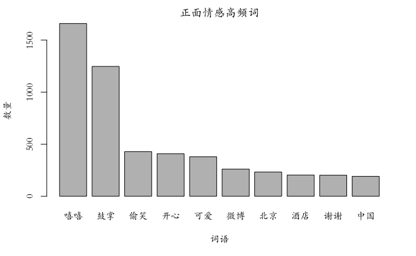

```r
#为词频最高的10个词语绘制直方图
postive_freq_top10 <- positive_word_freq$freq[1:10]
names(postive_freq_top10) <- positive_word_freq$word[1:10]
barplot(postive_freq_top10,family='STKaiti',main="正面情感高频词",xlab = '词语',ylab = '数量')
```

```r
#我们决定用worldcloud2和worldcloud两个包分别绘制词云
library(wordcloud2)
#经过尝试星型图、三角形图等，最终还是选择了默认的circle
wordcloud2(positive_word_freq[, c("word", "freq")], size = 2.6, shape = "circle", color = "random-light",
    backgroundColor = "black")
```

[interactive chart not shown]

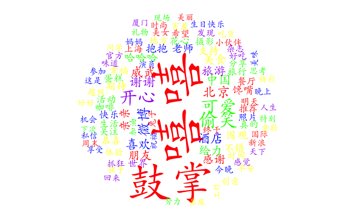

```r
#worldcloud包绘制图云的过程，选用两种包我们更多是为了比较选择更美观的一个。
#指定字体颜色范围  或者使用R颜色程序包中现成的主题模板
colors = c('red', 'blue', 'green', 'yellow', 'purple')
#读取数据,显示图形，参数即为颜色大小背景等图形的参数
wordcloud::wordcloud(
positive_word_freq$word,
positive_word_freq$freq,
scale = c(7, 0.9),
min.freq = 30,
max.words = 100,
colors = colors,
random.order = F,
random.color = T,
ordered.colors = F,
family='STKaiti'
)
```

## 3.3 负面情感

绘制负面情感词云的步骤和原理与以上类似，在此就不再赘述了：

```r
negative_raw_doc <- paste0(subset(sample_data,label==0)$review,',')
negative_word_freq <- cut_chinese_f(stop_word_path = "../Data/otherdata/stopword.txt",
    raw_doc = negative_raw_doc, drop_stop = TRUE, drop_number = TRUE, drop_letter = TRUE)
head(negative_word_freq)
```

|  | word | tag | tag_chi | freq |
| --- | --- | --- | --- | --- |
| 14057 | 抓狂 | v | 动词 | 1357 |
| 23017 | 微博 | x | 非语素字 | 283 |
| 14949 | 偷笑 | v | 动词 | 254 |
| 3605 | 蜡烛 | n | 名词 | 238 |
| 11126 | 北京 | ns | 地名 | 223 |
| 23662 | 嘻嘻 | z | 状态词 | 206 |

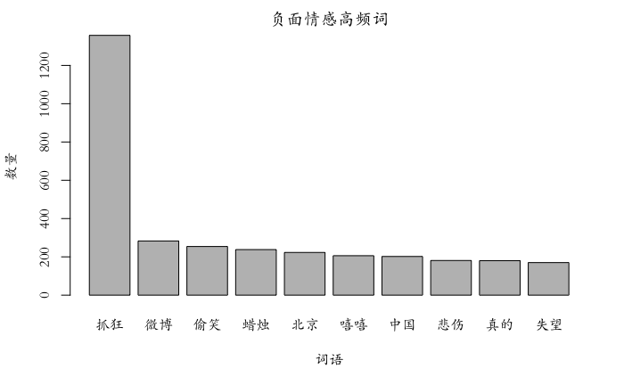

```r
negative_freq_top10 <- negative_word_freq$freq[1:10]
names(negative_freq_top10) <- negative_word_freq$word[1:10]
barplot(negative_freq_top10,family='STKaiti',main="负面情感高频词",xlab = '词语',ylab = '数量')
```

负面的高频词比较奇怪，混入了北京、嘻嘻、等没有区分度的词语。

```r
library(wordcloud2)
wordcloud2(negative_word_freq[, c("word", "freq")], size = 2.6, shape = "circle", color = "random-light",
    backgroundColor = "black")
```

[interactive chart not shown]

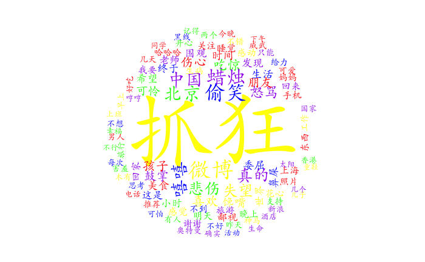

```r
colors = c('red', 'blue', 'green', 'yellow', 'purple')
wordcloud::wordcloud(
negative_word_freq$word,
negative_word_freq$freq,
scale = c(9, 0.6),
min.freq = 30,
max.words = 100,
colors = colors,
random.order = F,
random.color = T,
ordered.colors = F,
family='STKaiti'
)
```

绘制词云本身并不复杂，我们的精力更多集中在了如何绘制美观、直观、可以明确反映数据集特点的词云。为此，我们反复尝试，在去除特殊字符、停用词、数字的基础上，又改进去除了单字和“回复”“转发”等特殊词语。最终，正面情感的词云和高词频词都基本符合我们的预期，但在负面情感中嘻嘻、北京等词的高频出现令我们不解。我们认为，“嘻嘻”的高频出现与微博表情“嘻嘻”和反讽语气有关，但对“北京”的高频出现仍感到不解。这也是我们需要深入研究和改进的地方。

# 4 数据处理

## 4.1 数据展示

我们读取了下载好的原始数据，随机抽取1w的数据，并且设置了随机数种子，使得作为本次的实验数据能保证在抽样条件下前后统一，且方便组员比较结果：

```r
# 读取原始的语料
rawdata <- read.csv('/Users/liuyinuo/Desktop/190519-R 文本分类/Data/rawdata/weibo_senti_100k.csv',stringsAsFactors=FALSE)
# 设置随机数种子
set.seed(12345)
# 抽取1w个样本
sample_data <- rawdata[sample(1:119988,10000),]
# 删除rawdata变量，该变量占用较多的内存
rm(rawdata)
```

我们将元素名称命名为0、1，分别代表负向和正向：

```r
#freq_tb：抽样的标签列
freq_tb <- table(sample_data$label)
#修改元素名称0负向 1正向
names(freq_tb) <- c('负向','正向')
freq_tb
```

```
负向 正向
4997 5003
```

由此表示我们的数据集中包含负向评论4997条，正向评论5003条。

我们将上述结果进行可视化展示：

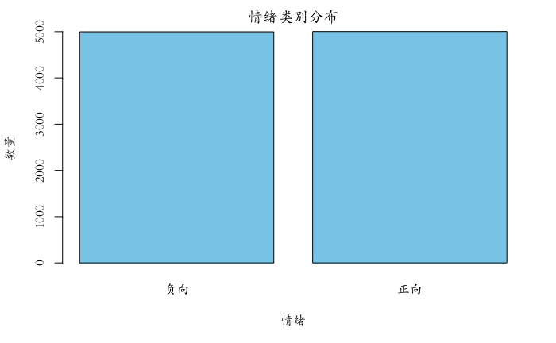

```r
## 全局关闭警告
options(warn = -1)
#画情绪类别分布直方图统计各自样本数量
barplot(freq_tb,family='STKaiti',main="情绪类别分布",xlab = '情绪',ylab = '数量',col = "skyblue")
```

## 4.2 数据预处理

### 4.2.1 分词处理

这部分的主要对每一条微博内容，进行分词，为后面的数据预处理进行准备。创建分词函数，主要使用jiebaR这个包和一些r语言基本函数，对数字、英文字母、单个字进行过滤。有很多文档，有很多个词语，把这些词每个词分成一列，把频数加在里面:

```r
# 参数说明：
## 1.stop_word_path 停用词文件路径
## 2.raw_doc 原始文本，字符串格式
## 3.drop_number是否过滤数字
## 4.drop_letter是否过滤英文字母
## 5.drop_oneword是否过滤单个字
cut_chinese_f_new <-
  function(stop_word_path,
  raw_doc,
  drop_stop = TRUE,
  drop_number = TRUE,
  drop_letter = TRUE,
  drop_oneword = TRUE) {
  # 调用分词函数worker
  wk <- jiebaR::worker()
  # 把'咚咚锵'作为一个词，进行分词
  jiebaR::new_user_word(wk, "咚咚锵", "n")
  # seg_word是分完词的（正/负）文档
  seg_word <- wk[raw_doc]
  # 去除停用词
  if (drop_stop) {
  # 读取停用词的txt文件 stop_word:停用词
  stop_word <- readLines(stop_word_path)
  # 如果分词之后的结果在停用词里面，则删掉
  #unlist将list数据变成字符串向量或者数字向量的形式
  seg_word <- unlist(lapply(
  seg_word,
  FUN = function(x) {
  #a %in% table :a值是否包含于table中，为真输出TURE，否者输出FALSE
  if (!x %in% stop_word) {
  return(x)
  }
  }
  ))
  }
  # 去除数字
  # 使用正则的方式，如果有0-9，则删掉
  if (drop_number) {
  seg_word <- unlist(lapply(
  seg_word,
  FUN = function(x) {
  if (!stringr::str_detect(x, "[0-9]+")) {
  return(x)
  }
  }
  ))
  }
  # 去除英文字母
  # 同样使用正则的方式
  if (drop_letter) {
  seg_word <- unlist(lapply(
  seg_word,
  FUN = function(x) {
  if (!stringr::str_detect(x, "[A-z]+")) {
  return(x)
  }
  }
  ))
  }
  # 去除单个字的情况
  # 判断字符串长度，如果为1，就删掉
  if (drop_oneword) {
  seg_word <- unlist(lapply(
  seg_word,
  FUN = function(x) {
  if (nchar(x) != 1) {
  return(x)
  }
  }
  ))
  }
  # 去除某些专业词汇
  # 转发和回复，属于微博中高频、无用的词，删掉
  professional_word <- c('转发', '回复')
  seg_word <- unlist(lapply(
  seg_word,
  FUN = function(x) {
  if (!x %in% professional_word) {
  return(x)
  }
  }
  ))
  # 按照空格拼接分词的结果，把一个文本分词后的n个词，拼接成字符串
  # 目的是为了后期用'咚咚锵'split文件
  return(paste0(seg_word, collapse = ' '))
  }
```

我们发现整个原始数据集中没有“咚咚锵”这个词，于是我们进行分词的方法进行创新，按照“咚咚锵”粘贴成一个大的字符串，再将“咚咚锵”作为一个“分隔符”，对文本进行分词，这样就比一行一行分词容易很多，也是我们的创新之处。并且我们养成了将新向量新增一列label的习惯，方便后续对比模型准确度。

```r
# sample_data新增id这一列
sample_data$id <- 1:nrow(sample_data)
# 改变sample_data的行名
rownames(sample_data) <- 1:nrow(sample_data)
# 对所有的微博内容，按照' 咚咚锵 '粘贴成一个大的字符串
whole_review <- paste0(sample_data$review,collapse = ' 咚咚锵 ')
# 调用分词函数，对whole_review这个大的字符串进行分词
whole_segword <- cut_chinese_f_new(stop_word_path='/Users/liuyinuo/Desktop/190519-R 文本分类/Data/otherdata/stopword.txt', raw_doc=whole_review)
# 分词返回的也是一个大的字符串
# 按照'咚咚锵'split
spilt_segword <- unlist(strsplit(whole_segword,'咚咚锵'))
# 复制sample_data
doc2word_df <- sample_data
# 把split之后的向量，作为doc2word_df的新增列，方便与review对比查看分词准确度
doc2word_df$segword <- spilt_segword
```

查看最后的数据。

```r
head(doc2word_df)
```

### 4.2.2 数据集拆分和特征生成

这部分属于建模的准备过程，包括数据集的拆分和特征生成，按照7:3的比例，对1w的sample_data进行拆分。我们设置了随机种子，一个特定的种子可以产生一个特定的伪随机序列，这个函数的主要目的，是让模拟能够可重复出现，因为之前我们随机抽取了样本，当这段代码再跑一次的时候，结果就不一样了，很影响后续结果分析，所以如果需要重复出现同样的模拟结果的话，就可以用set.seed()。在调试程序或者做展示的时候，结果的可重复性是很重要的，所以随机数种子也就很有必要。可以简单理解为括号里的数只是一个编号而已，此代码中set.seed(12345)不应将括号里的数字理解成“12345”，而是应该理解成“编号为12345的随机数发生”，下一次再模拟采用不同的编号即可：

```r
# 设置随机数种子set.seed()
set.seed(12345)
# 随机抽样，7k的数据,train_index是从10k中抽出的7k个随机行号
train_index <- sample(1:10000,10000*0.7)
# 求差集函数setdiff，把剩下的30%数据去除
test_index <- setdiff(1:10000,train_index)
# 上面取出的是行号，提高效率，下面直接取行号对应的数据
trainset_raw <- doc2word_df[train_index,] #训练数据集
testset_raw <- doc2word_df[test_index,] #测试数据集
```

### 4.2.3 特征生成-词矩阵

基本逻辑是把所有的词生成向量，比如1000个词，就有1k的特征。对应每一个文档，都有1k特征，这些特征的实际含义为词频：

```r
head(trainset_raw$segword)
```

```
[1] " 李倩玲 失望 南方 都市报 这组 定点 拍摄 京城 消失 连续 地点 观测 北京 空气质量 污染 程度 惊人 摄影师 连续 两周 关注 朝阳区 核心区 中国 传媒大学 一带 空气质量 "
[2] " 世上 妈妈 老妈 生日 过好 嘻嘻 家人 时光 幸福 时光 蛋糕 "
[3] " 包裹 大号 玫红 "
[4] " 羽绒服 感冒 穿着 抓狂 "
[5] " 鼓掌 支持 "
[6] " 新歌 心情 不好 推荐 首歌 夏天 夏天 夏天 "
```

这里用到了文本挖掘包tm。VectorSource函数将一个文本向量创建为一个向量源，向量源解释向量的每一个元素作为一个文档；trainset_raw$segword为一个向量的文本。Corpus函数：语料库的呈现与计算，(语料库是包含（自然语言）文本的文档集合)：

```r
review_corpus <- tm::Corpus(tm::VectorSource(trainset_raw$segword))
# 创建文档-利用tm包里的DocumentTermMatrix函数生成单词矩阵
review_dtm <-  tm::DocumentTermMatrix(review_corpus)
# 把在review中出现数目超过25个的词筛选出来
review_words_dict <-tm::findFreqTerms(review_dtm,lowfreq=25)
# 计算数目一共331个
length(review_words_dict)
```

```
[1] 331
```

下面基于这331个数据，创建新的文档-词矩阵：

```r
#基于这331个数据，创建训练数据集的文档-词矩阵
review_train_dtm_freq <- tm::DocumentTermMatrix(tm::Corpus(tm::VectorSource(trainset_raw$segword)),
                                                list(dictionary = review_words_dict))

#基于这331个数据，创建测试数据集的文档-词矩阵
review_test_dtm_freq <- tm::DocumentTermMatrix(tm::Corpus(tm::VectorSource(testset_raw$segword)),
                                               list(dictionary = review_words_dict))
```

### 4.2.4 词矩阵示例

查看下具体数据,以文档1257为例：

```r
#查看文档1257的review
tm::inspect(review_test_dtm_freq[1257,])
```

[output not shown]

```r
tm::inspect(review_train_dtm_freq[1257,])
```

[output not shown]

```r
#查看文档1257的分词，与review对照能核对上
testset_raw[1257,]$segword
```

```
[1] " 丫头 是啊 微博 四站 公交车 提前 分钟 出门 发车 分钟 火车 丫头 吃惊 丫头 公主 殿下 丫头 胜胜 是因为 作弄 遭报应 了么 吃惊 失望 生病 委屈 可怜 悲伤 "
```

通过对比，数据能核对上，值得注意的是这里的Docs编号是按照testset_raw的顺序来的。

### 4.2.5 数据格式转换

把文档-词频矩阵直接转换成data.frame,方便数据处理：

```r
#把数据稀疏矩阵变为普通矩阵再变为数据框，因为最后需要这样的数据，便于后续处理
tr<-as.matrix(review_train_dtm_freq)
te<-as.matrix(review_test_dtm_freq)
train_final_df<-data.frame(tr)
test_final_df<-data.frame(te)
```

```r
#可查看一下处理后的效果
View(train_final_df)
```

把segword也加上去看看，看看数据是否一一匹配：

```r
#把segword加到训练数据框看数据是否一一匹配
train_final_df$segword <- trainset_raw$segword
#把segword加到测试数据框看数据是否一一匹配
test_final_df$segword <- testset_raw$segword
```

```r
#列出该行词向量>0的词
j <- 10
x <- c()
for (i in 1:(ncol(train_final_df)-1)){
  if(train_final_df[j,i]>0){
    x <- c(x,i)
  }
}
train_final_df[j,c(x,ncol(train_final_df))]
```

[output not shown]

```r
NA
```

数据核对没有问题，有的词没有出现，是因为他出现在别的doc中的情况比较少。重新梳理数据，把数据稀疏矩阵变为普通矩阵再变为数据框，因为最后需要这样的数据，便于后续处理。

```r
#重新梳理数据，把数据稀疏矩阵变为普通矩阵再变为数据框，因为最后需要这样的数据，便于后续处理
tr<-as.matrix(review_train_dtm_freq)
te<-as.matrix(review_test_dtm_freq)
train_final_df<-data.frame(tr)
test_final_df<-data.frame(te)
```

把label列加上去，并且需要转置为factor：

```r
#把label列加上去，原来是Int型，应转置为因子型
train_final_df$y <- as.factor(trainset_raw$label)
test_final_df$y <- as.factor(testset_raw$label)
```

# 5 情感分类算法

## 5.1 随机森林

### 5.1.1 算法原理

随机森林需要先知道的知识是决策树，那么通过以前课程的学习，我们已经知道决策树就是利用信息增益进行衡量的，信息增益越大，则分类效果越好。而随机森林是指，对数据集中的列变量以及行观测进行随机化（即随机），会生成不同的分类树，这些树都是独立同分布的决策树（备注：这些决策树是没有经过剪枝，也就是处于过拟合的状态），每一棵树都依赖一个随机向量，最后进行汇总（即构成森林）。

- 两个重要属性 第一，树节点的变量个数，即随机产生m个变量  
  第二，随机森林中树的个数，即放回随机抽取k个样本集，训练成k个决策树
- 两个评价因素  
  第一，第一每棵树生长越茂盛，组成森林的分类性能越好；  
  第二，每棵树之间的独立性越强，则森林的分类性能越好。 减小特征选择个数m，树的相关性和分类能力也会相应的降低；增大m，两者也会随之增大。所以关键问题是如何选择最优的m（或者是范围）以及如何让调整树的个数k，这是随机森林分类算法中最重要的两个参数。
- 举例说明  
  在商务智能与数据挖掘的课程学习中，我们对决策树进行了详细的学习，包括算法原理、代码编程以及具体实例的应用，了解到其算法的核心是计算信息增益，最大的缺点便是会出现过拟合的问题。而在近日学习的机器学习课程中，我们又学习到了一种先进的机器学习形式——随机森林，这要求我们不仅要构建一颗树，而是要构建N棵不同形式的树，从每棵树会得到不同的结果，此时我们需要记录哪个输出得票最多，得票最多的输出为该森林的输出结果。 比如我们假设为一个二分类问题，设置输出树的个数为三，其结果为下图所示：

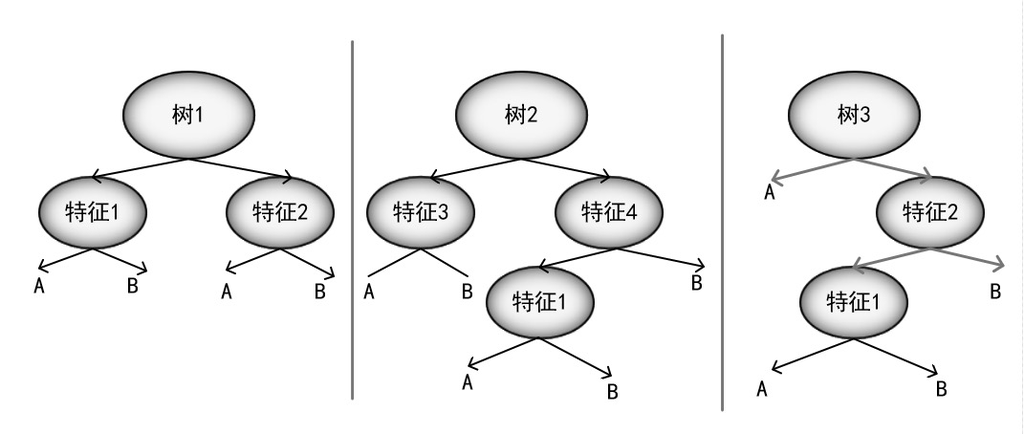

```r
image_path = "../Picture/WechatIMG12.png"
rmarkdown::html_notebook_output_img(path = image_path, format = "png")
```

图中显示的有三颗不同的树，每个树的输出要么是A类，要么是B类，假设当我们以某种输入传递给这三棵树构成的森林，得到的预测结果为：树1：A 树2：B 树3：A  
那么，通过投票数最多的输出，作为随机森林的最终答案，在上述例子中随机森林的答案便是A类。

## 5.1.2 算法流程

通过上述介绍，我们将随机森林的算法流程绘制为流程图可得：

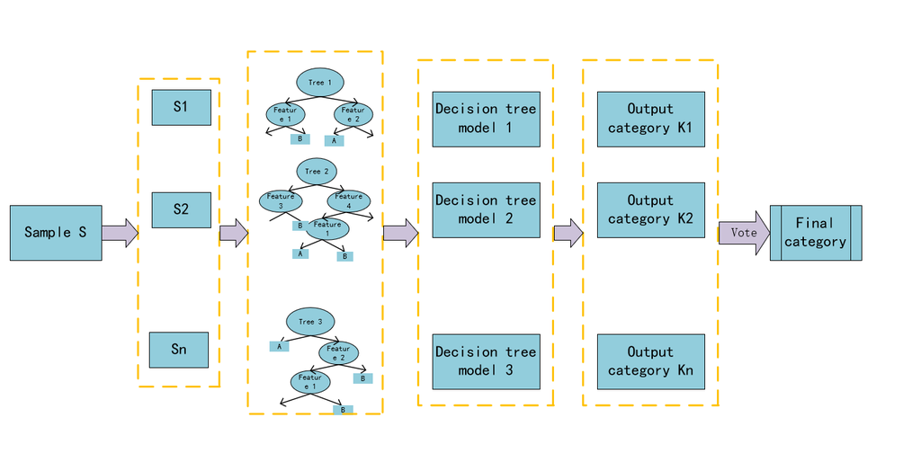

```r
image_path = "../Picture/WechatIMG11.png"
rmarkdown::html_notebook_output_img(path = image_path, format = "png")
```

## 5.1.3 参数介绍

通过网络介绍以及查看help文档，可以得知随机森林randomForest中的参数列表。

##### xtest,ytest

分别代表测试集的特征矩阵以及响应变量  
##### ntree 为树的数量，其默认为500棵，这是我们可以调的参数

##### mtry

是指训练时选择的特征数，默认值为sqrt(p),这同样是我们要重点调的一个参数

##### replace

来表示是否进行重复抽样，在这里默认值为TRUE，表示进行重复抽样

##### strata

表示分层抽样，为因子型变量

##### nodesideh

分别表示决策树节点的最小个数，默认分类为1

##### maxnodesbi

表示决策树节点的最大个数，默认尽可能的生长

##### importance

为布尔型，即是指是否返回变量重要性的排序，默认为FALSE。其中locallmp与importance只能取一个

##### proximity

表示是否计算行之间的相似度

##### oob.prox

表示是否计算袋外数据的相似度，也就是指的是袋外误，即错误率

##### norm.votes

表示投票结果是否用分数表示，默认为TRUE，剩余均为一些不重要的参数。

## 5.2 svm

### 5.2.1 算法原理

svm（support Vector Mac）又称为支持向量机，支持向量机可以分为线性核非线性两大类。其主要思想为寻找一个超平面作为分类决策面实现对正例和反例的分割,并尽量使两个类别之间的空白间隔最大,以保证分类的高可信度。支持向量机在解决小样本、非线性以及高维模式识别中有许多独特的优势,它是以统计学习理论和结构风险最小化原理为基础,根据样本有限的条件,在模型复杂度和机器学习能力之间寻找最佳折衷, 来提高机器学习的泛化能力。

算法原理图

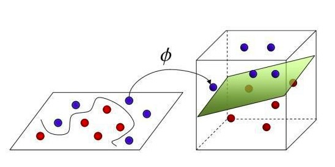

```r
image_path = "../Picture/svm.png"
rmarkdown::html_notebook_output_img(path = image_path, format = "png")
```

在线性的情况下,该问题可以归结为一个二次规划问题。但现实生活中的问题往往是非线性问题，在非线性的情况下,可以将输入向量利用核函数映射到一个高维的特征空间, 在高维空间非线性的问题仍然可以转化为线性可分问题。

在文本分类中, 支持向量机是一种效果显著的方法。支持向量机将文本数据转化为支持向量,通过算法得到决策平面,从而解决文本分类问题。Thorsten Joachims将核函数引入SVM中,用线性核函数解决非线性的分类问题,将低维空间数据用核函数变换到高维空间中去,然后在转换后的高维空间找分割平面,期望使得分割平面两侧到训练点的间隔最大。按照文本预处理和文本特征向量选择得到训练样本的特征向量,根据特征向量训练得到一个训练模型,最终将利用这个训练模型对待分类的测试样本进行分类识别。

### 5.2.2 算法流程

将该算法步骤总结为流程图：

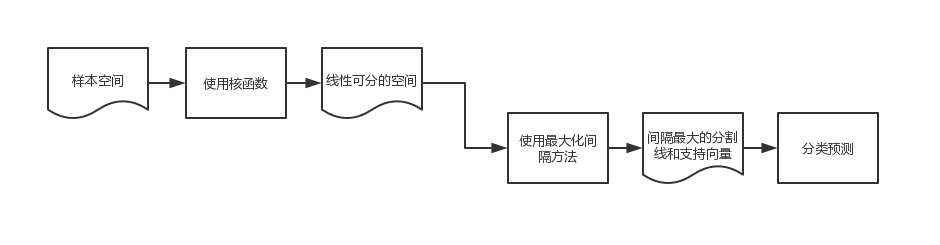

```r
image_path = "../Picture/svmprocess.png"
rmarkdown::html_notebook_output_img(path = image_path, format = "png")
```

### 5.2.3 参数介绍

- kernel（核函数）是SVM算法应用于文本分类问题最重要的一个参数，下方为其常用属性列表：

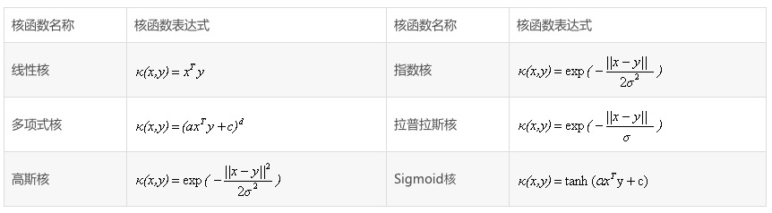

```r
image_path = "../Picture/k.png"
rmarkdown::html_notebook_output_img(path = image_path, format = "png")
```

##### degree

是仅用于多项式核函数中的参数，代表多项式核函数的次数，当degree高于15时，R出现警告信息，而且当样本数据量较大时，设置过高的degree将非常危险。默认为3。

##### cost

是惩罚因子，可与任意核函数搭配，cost与degree通常配合使用，在研究他们时，使用交叉验证法会得到更精确的结果。

##### decision.values

逻辑控制的决定是否值二分类多类分类计算应计算并返回。

##### probability

逻辑类的概率是否应计算并返回。只有可能的如果模型拟合probability选项，启用。

##### na.action

一个函数来指定动作时要采取“不适用的发现。默认的操作是na.omit，这会导致排斥反应的情况下，任何所需的变量的遗漏值。另一种方法是na.fail，这会导致错误如果NA情况。如果给定，该参数必须被命名。

## 5.3 xgb

### 5.3.1 算法原理

XGBoost全名叫（eXtreme Gradient Boosting）极端梯度提升，它是大规模并行boosted tree的工具，是一种tree boosting的可扩展机器学习系统，也是监督学习的一种，是一种基于分类和回归树的算法，属于连续的集成学习模型。

其基本思想通过一系列弱分类器的迭代计算实现准确的分类效果，就是不断地添加树，不断地进行特征分裂来生长一棵树，每次添加一个树，就是学习一个新函数，去拟合上次预测的残差。当训练完成得到k棵树，要预测一个样本的分数，就是根据这个样本的特征，在每棵树中会落到对应的一个叶子节点，每个叶子节点就对应一个分数，最后只需要将每棵树对应的分数加起来就是该样本的预测值。

XGBoost是以CART树中的回归树作为基分类器，在给定训练数据后，其单个树的结构(叶子节点个数、树深度等等)基本可以确定了。但XGBoost并不是简单重复的将几个CART树进行组合。它是一种加法模型，将模型上次预测产生的误差作为参考进行下一棵树的建立。以此，每加入一棵树，将其损失函数不断降低。例如一个人的年龄为20岁，第一次预测其年龄为12岁，那么残差为8岁，第二次对8进行预测，预测结果为5时，残差为3，以此类推。

如下图就为加法模型案例，它将模型预测值与实际值残差作为下一颗树的输入数据。

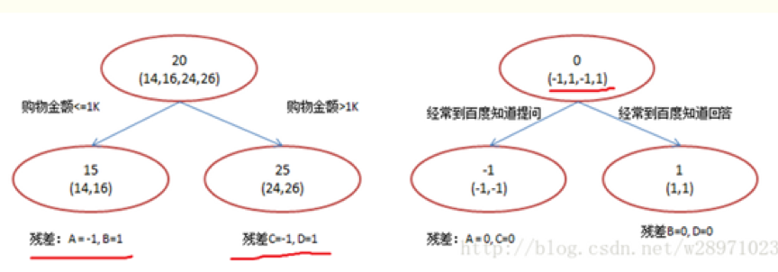

```r
image_path = "../Picture/xgb1.png"
rmarkdown::html_notebook_output_img(path = image_path, format = "png")
```

- 例子  
  > 如下图例子，训练出了2棵决策树，小孩的预测分数就是两棵树中小孩所落到的结点的分数相加。爷爷的预测分数同理。

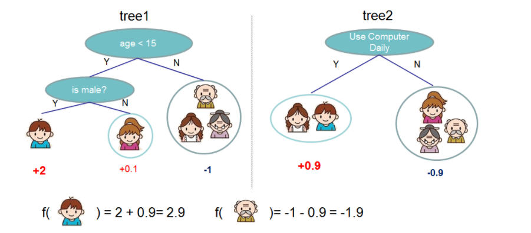

```r
image_path = "../Picture/xgb2.png"
rmarkdown::html_notebook_output_img(path = image_path, format = "png")
```

### 5.3.2 算法流程

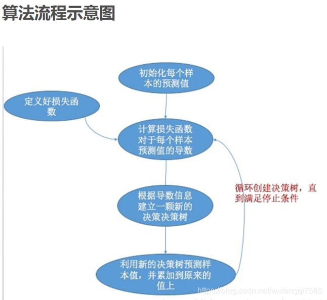

```r
image_path = "../Picture/xgb3.png"
rmarkdown::html_notebook_output_img(path = image_path, format = "png")
```

- 通过例子简单描述  
  比如预测学生考试分数，给定若干个学生属性（比如天赋，每天学习时间，是否恋爱等等），通过一个决策树A，可以看到一个通过天赋属性的预测结果:天赋高的人分数+90，天赋低的人+60；通过一个决策树B，可以看到每天学习时间<10小时会使得考试分数收到-5的影响，以此类推可以通过学生的属性推断其分数情况。

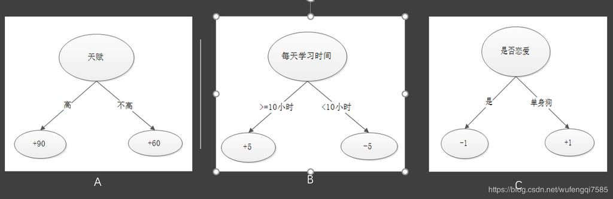

```r
image_path = "../Picture/xgb4.png"
rmarkdown::html_notebook_output_img(path = image_path, format = "png")
```

XGboost就是这样一个不断生成新的决策树A,B,C,D…的算法，最终生成的决策树算法就是树A+B+C+D+…的和的决策树。

使用Xgboost的优势在于快速对特征级数据进行训练,预测结果精度高,并且Xgboost可以有效解决高维度问题,具有数据处理快和准确度较高的特点。

### 5.3.3 参数介绍

#### –通用型参数

—-参数决定在提升的过程中用哪种booster

##### booster

gbtree 树模型做为基分类器（默认）  
gbliner 线性模型做为基分类器

##### silent

silent=0时，输出中间过程（默认），帮我们更好的理解模型。  
silent=1时，静默模式开启，不会输出任何信息。

##### nthread

这个参数用来进行多线程控制，应当输入系统的核数。  
默认是当前系统最大线程数。

##### scale_pos_weight

正样本的权重，在二分类任务中，当正负样本比例失衡时，设置正样本的权重，模型效果更好。  
例如，当正负样本比例为1:10时，scale_pos_weight=10。

#### –模型参数

—-该参数的设置依赖于选择哪一种booster模型

##### n_estimatores

总共迭代的次数，即决策树的个数

##### early_stopping_rounds

在验证集上，当连续n次迭代，分数没有提高后，提前终止训练。  
调参：防止overfitting。

##### max_depth

树的最大深度，默认值为6，用来避免过拟合；典型值3-10。  
调参：值越大，越容易过拟合；值越小，越容易欠拟合。

##### min_child_weight

决定最小叶子节点样本权重和。  
当它的值较大时，可以避免模型学习到局部的特殊样本。但如果这个值过高，会导致欠拟合。这个参数需要用cv来调整。  
默认值为1。  
调参：值越大，越容易欠拟合；值越小，越容易过拟合（值较大时，避免模型学习到局部的特殊样本）。

##### Subsample

这个参数控制对于每棵树，随机采样的比例。  
减小这个参数的值算法会更加保守，避免过拟合。但是这个值设置的过小，它可能会导致欠拟合。  
含义：训练每棵树时，使用的数据占全部训练集的比例。默认值为1，典型值为0.5-1。  
调参：防止overfitting。

##### colsample_bytree

用来控制每颗树随机采样的列数的占比每一列是一个特征。  
训练每棵树时，使用的特征占全部特征的比例。默认值为1，典型值为0.5-1。  
调参：防止overfitting。

##### colsample_bylevel

默认是1，用来控制的每一级的每一次分裂，对列数的采样的占比。

##### max_leaf_nodes

树上最大的节点或叶子的数量，可以代替max_depth的作用，应为如果生成的是二叉树，一个深度为n的树最多生成2n个叶子,如果定义了这个参数max_depth会被忽略 。

##### gamma

默认是0。在节点分裂时，只有在分裂后损失函数的值下降了，才会分裂这个节点。  
Gamma指定了节点分裂所需的最小损失函数下降值。这个参数值越大，算法越保守。

##### max_delta_step

默认是0。这参数限制每颗树权重改变的最大步长。  
如果是0意味着没有约束。如果是正值那么这个算法会更保守，通常不需要设置。

##### alpha

L1正则化系数，默认为1

##### lambda

L2正则化系数，默认为1

#### –学习任务参数

—-参数的设置决定着哪一种学习场景

##### learning_rate

学习率，控制每次迭代更新权重时的步长，默认0.3。  
调参：值越小，训练越慢。  
典型值为0.01-0.2。

##### objective 目标函数

定义需要被最小化的损失函数。  
最常用的值有：binary：logistic二分类的逻辑回归，返回预测的概率非类别。  
o 回归任务  
reg:linear (默认)  
reg:logistic  
o 二分类  
binary: logistic 概率  
binary：logitraw 类别  
o 多分类 multi：softmax num_class=n 返回类别  
multi：softprob num_class=n 返回概率

##### eval_metric—-默认值取决于objective参数的取之

o 回归任务(默认rmse)  
rmse–均方根误差  
mae–平均绝对误差  
o 分类任务(默认error)  
auc–roc曲线下面积  
error–错误率（二分类）  
merror–错误率（多分类）  
logloss–负对数似然函数（二分类）  
mlogloss–负对数似然函数（多分类）

##### seed

默认是0。随机数的种子，设置它可以复现随机数据的结果，也可以用于调整参数。

## 5.4 朴素贝叶斯

### 5.4.1 算法原理

朴素贝叶斯分类是基于贝叶斯定理的一种分类方法。主要依据原理是已知P(B|A)=P(AB)/P(A)，利用P(A|B)=P(B|A)*P(A)/P(B),求P（A|B），也就是说我们把自己求出的分类在训练数据集中先分好，然后计算在不同分类中各个属性的属性值或范围对应的概率相当于P（B|A），然后根据属性分类概率P（B），所求分类概率P（A），判断已知属性的样本的分类。

### 5.4.2 算法流程

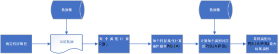

```r
image_path = "../Picture/WechatIMG80.png"
rmarkdown::html_notebook_output_img(path = image_path, format = "png")
```

### 5.4.3 参数介绍

##### naiveBayes

(formula, data, laplace = 0, …, subset, na.action = na.pass)

##### formula

公式的调用 ,也可以是一个无分类标签的矩阵。

##### data

数据

##### laplace

拉普拉斯平滑，优化参数。

##### X

指定需要处理的数据，可以是数据框形式，也可以是矩阵形式；

##### subset

子集，对于数据框中给定的数据，指定训练样本中使用的用例的索引向量。(注意:如果给定，这个参数必须被命名。)

##### na.action

一个用于指定如果找到NAs将采取的操作的函数。默认操作是不计算它们的概率因子。另一种选择是NA。省略，这将导致拒绝任何必需变量上缺少值的情况。(注意:如果给定，这个参数必须被命名。) 对象

##### object

“naiveBayes”的对象。

##### newdata

带有新预测的数据框(列可能比训练数据少)。注意，newdata的列名与训练数据的列名相匹配。type 如果type=”raw”,则返回每个对象的条件后验概率，以及其他具有最大概率的对象。

##### threshold

替换单元格的概率在eps范围内。

##### eps

double值，用于指定应用拉普拉斯平滑的量程(用保留值替换零或接近零的概率)。

# 6 情感分类算法实现

> 名词解释：  
> （1）roc曲线  
> 其横轴为负正类率(false postive rate FPR)特异度，划分实例中所有负例占所有负例的比例；(1-Specificity)；roc曲线的纵轴为真正类率(true postive rate TPR)灵敏度，Sensitivity(正类覆盖率)。若模型十分准确，则AUC为1。但现实生活中不会有如此完美的模型，一般AUC均在0.5到1之间，AUC越高，模型的区分能力越好。  
> （2）等误差率 roc曲线图左上角标出的点为equal error rate，即等误差率，用来提前确定该系统的错误接受率和错误拒绝率的阈值。  
> 这个值就是错误接受率和错误拒绝率相等时的值。这个值越低则表明这个生物特征安全系统越精确。  
> （3）精准率和召回率  
> 评判分类效果的两个指标，它们和之前ROC曲线中的准确率还不同，一个表示查准率一个表示查全率。此外，对于二类分类问题常用的评价指标是精确率（precision）与召回率（recall）。 - 召回率（recall）是指针对原来样本而言，表示有多少样本中的正例（一种是把正类预测为正类即TP，一种是把正类预测为负类即FN）被预测正确了。  
> - 精确率（precision）：是针对预测结果而言，表示的是预测为正的样本中（一种是把正类预测为正类即TP，一种是把负类预测为正类即FP）有多少是真正的正样本。  
> 精准率和召回率都高时，F1值也会高。

## 6.1 随机森林

### 6.1.1 第一次训练

在没有进行调参之前，我们并不知道应该选取哪些变量以及多少决策树，因此在第一次跑程序时我们选取默认的500棵树以及sqrt(p)个特征变量，查看行之间的相似度并取袋外误差，展示变量重要性的排序。

```r
set.seed(1)#设置随机数种子
#调用randomFprest模型
#这个一个小技巧，当存在很多变量时用y~.来表示，"."代表x
rf_model <-
  randomForest::randomForest(
    y ~ .,
    train_final_df,#表示数据集，在这里要使用数据框的形式导入数据
    proximity = TRUE,#显示行之间的相似度，这样也可以获取袋外误差
    importance = TRUE,#显示变量的重要性顺利
    ntree = 500,#500个树
  )
```

查看第一次默认情况下的执行效果：

```r
rf_model
```

```
Call:
 randomForest(formula = y ~ ., data = train_final_df, proximity = TRUE,      importance = TRUE, ntree = 500, )
               Type of random forest: classification
                     Number of trees: 500
No. of variables tried at each split: 26

        OOB estimate of  error rate: 22.2%
Confusion matrix:
     0    1 class.error
0 2721  752   0.2165275
1  802 2725   0.2273887
```

### 6.1.2 调参

通过对函数参数的理解和认识，这里最重要的两个参数便是树的个数以及参与训练的变量的个数，因此下面的调参依次是对决策树个数以及变量个数的调整。先调整决策树棵树，若按照10，20…500调参数,会发现很难调成功，因此下面代码是看100…500这几种树的棵树，哪一个oob(袋外误差)最小，就把树的棵树设置为这个参数：

```r
#通过每棵树的错误率，我将调参的范围限制在100-500棵之间，步长为50
#其他参数不变，重复第一次训练时的代码样本，调整参数如下
for(i in seq(from = 200,to = 500,by = 50)){
  sub_rf_model <- randomForest::randomForest(y~.,data = train_final_df,ntree = i,mtry=26)
  cat(paste0("ntree = ",i,"; OOB=",(sub_rf_model$err.rate[i,1])),"\n")
}
```

```
ntree = 200; OOB=0.223
ntree = 250; OOB=0.223571428571429
ntree = 300; OOB=0.223857142857143
ntree = 350; OOB=0.223428571428571
ntree = 400; OOB=0.222
ntree = 450; OOB=0.222571428571429
ntree = 500; OOB=0.224285714285714
```

结论：通过上面的数据显示，我们发现决策树取200-500颗的都差不多，均为22%左右，那么为了能够训练出最好的模型，我认为决策树为400时就比较合适。

同理，将决策树的个数设置为400颗，调整另一个重要参数mtry（变量的个数），将变量个数限定在15-35之间，步长为5:

```r
#调整最佳到最佳决策树个数，重复第一次训练时的代码样本，调整参数如下
for(j in seq(from = 15,to = 35,by = 5)){
  sub_rf_model <- randomForest::randomForest(y~.,data = train_final_df,ntree = 400,mtry = i)
  cat(paste0("mtry = ",j,"; OOB=",(sub_rf_model$err.rate[100,1])),"\n")
}
```

```
mtry = 15; OOB=0.237428571428571
mtry = 20; OOB=0.237857142857143
mtry = 25; OOB=0.236714285714286
mtry = 30; OOB=0.235
mtry = 35; OOB=0.235571428571429
```

结论：通过上面的数据显示，我们发现变量个数在15-35之间的外袋误差相差不大，均为23%左右，我认为变量的个数取30时就比较合适。

### 6.1.3 最终训练模型

通过调参，可以得到，最佳决策树的个数为400，最佳变量个数为30。即将ntree=400，mtry=30。

```r
set.seed(1)#设置随机数种子
rf_model <-
  randomForest::randomForest(
    y ~ .,
    train_final_df,
    proximity = TRUE,
    importance = FALSE,
    ntree = 400,
    mtry=30
  )
```

查看结果：

```r
rf_model
```

备注：由于跑一次随机森林大概需要两三个小时，并且调参后的外袋误差相差不大，因此用第一次训练模型的结果就可以当作最终模型。

### 6.1.4 训练模型可视化

#### 查看树的节点数

利用teesize显示决策树的叶子节点的个数（默认只计算每棵树的根节点）:

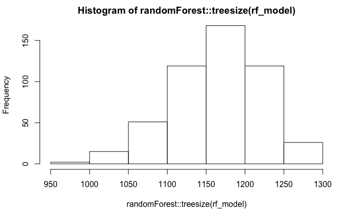

```r
hist(randomForest::treesize(rf_model))#绘制叶子节点的直方图
```

通过上图发现，随着模型中randomForest::treesize的变化，随机森林中每颗决策树的节点分布成正太分布，把并且当treesize的值为1150-1200时，达到峰值。

#### 绘制每棵树的误判率

为了能让我们更好观测决策树的集成情况，我们需要查看绘制决策树时的错误率，观察累积训练到第几棵树时错误率趋于稳定。因此，在这里使用plot函数绘制折线图：

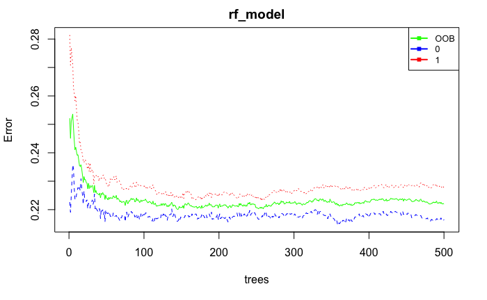

```r
plot(x=rf_model,type="l",col=c("green","blue","red"))
legend("topright",legend = colnames(rf_model$err.rate),col = c("green","blue","red"),pch=15,cex=0.8,lwd=2)
```

由上图可知，当树为100棵时,错误率趋于稳定，这也解释了上述调参的结果：即200-500棵树的外袋误差基本相同。

### 6.1.5 模型预测

使用predict函数可直接对训练集进行预测：

```r
#将训练集中的进行预测，并进行展示
pre_train2 <-
  predict(rf_model, train_final_df[1:(ncol(train_final_df) - 1)])
str(pre_train2)
```

```
 Factor w/ 2 levels "0","1": 1 2 1 1 2 1 2 1 1 2 ...
 - attr(*, "names")= chr [1:7000] "1" "2" "3" "4" ...
```

```r
#测试集进行预测，并进行展示
pre_test2 <-
  predict(rf_model, test_final_df[1:(ncol(test_final_df) - 1)])
str(pre_test2)
```

```
 Factor w/ 2 levels "0","1": 1 1 2 1 1 1 1 1 1 1 ...
 - attr(*, "names")= chr [1:3000] "1" "2" "3" "4" ...
```

```r
#测试集预测，并用概率的形式表示
prob_test2 <-
  predict(rf_model, test_final_df[1:(ncol(test_final_df) - 1)],type = 'prob')[,2]
str(prob_test2)
```

```
 Named num [1:3000] 0.244 0 0.998 0.132 0 0.284 0 0 0.008 0.308 ...
 - attr(*, "names")= chr [1:3000] "1" "2" "3" "4" ...
```

从上述运行的结果来看，一共个7000训练集，3000个测试集，图中显示的1，2表示的为因子水平，即代表lable的0，1。而最后一个的概率形式表示为lab=1的概率，大于0.5则认为是1。

### 6.1.6 模型效果

将上述运行好的模型预测结果，用数据的形式表达出来，即将预测正确的数据量除以原始的数据量。

```r
#将原数据转换为数据框的形式
table_train_df2 <- as.data.frame(table(pre_train2, train_final_df$y))
#利用简单计算将训练集的结果展示出来
x1 <-
sum(subset(table_train_df2, pre_train2 == Var2)$Freq) / sum(table_train_df2$Freq)

table_test_df2 <- as.data.frame(table(pre_test2, test_final_df$y))
#利用简单计算将测试集的结果展示出来
x2 <-
sum(subset(table_test_df2, pre_test2 == Var2)$Freq) / sum(table_test_df2$Freq)
#将上述结果输出
cat(paste0('训练集准确率：', x1, '\n', '测试集准确率：', x2))
```

```
训练集准确率：0.895857142857143
测试集准确率：0.770666666666667
```

训练集的准确率高达89.6%，测试集77.1%，很显然，不论是训练集还是测试集，准确率都比较高。

### 6.1.7 模型效果可视化

#### 混淆矩阵

```r
table(pre_train2,train_final_df$y)
```

```
pre_train2    0    1
         0 3174  430
         1  299 3097
```

#### ROC曲线

```r
#prob_test2为每个测试集的概率，test_final_df$y为每个变量的标签
pred <- ROCR::prediction(prob_test2,test_final_df$y)
# 计算AUC的值
ROCR::performance(pred,'auc')@y.values
```

```
[[1]]
[1] 0.8266016
```

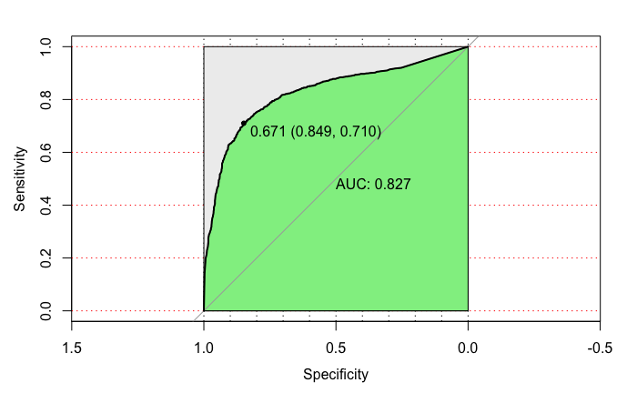

```r
# 画出AUC图像
a<-pROC::roc(test_final_df$y,prob_test2)
plot(a,print.auc=TRUE, auc.polygon=TRUE, grid=c(0.1, 0.2),
     grid.col=c("black", "red"), max.auc.polygon=TRUE,
     auc.polygon.col="lightgreen", print.thres=TRUE)
```

从上图可知，随机森林模型的AUC为0.827，效果良好，随机森林模型的等误差率为0.671，同样处于一个不低的水平。

#### 精准率，召回率，F值

```r
precision_0 <- sum(subset(table_test_df2,pre_test2==0&Var2==0)$Freq)/sum(subset(table_test_df2,pre_test2==0)$Freq)
precision_1 <- sum(subset(table_test_df2,pre_test2==1&Var2==1)$Freq)/sum(subset(table_test_df2,pre_test2==1)$Freq)

recall_0 <- sum(subset(table_test_df2,pre_test2==0&Var2==0)$Freq)/sum(subset(table_test_df2,Var2==0)$Freq)
recall_1 <- sum(subset(table_test_df2,pre_test2==1&Var2==1)$Freq)/sum(subset(table_test_df2,Var2==1)$Freq)

F_score_0 <- 2*(precision_0*recall_0)/(precision_0+recall_0)
F_score_1 <- 2*(precision_1*recall_1)/(precision_1+recall_1)

cat(paste0('测试集-label0精确率：',precision_0,'\n',
           '测试集-label0召回率：',recall_0,'\n',
           '测试集-label0 Fscore：',F_score_0,'\n'
           ),'\n')
```

```
测试集-label0精确率：0.77536231884058
测试集-label0召回率：0.772309711286089
测试集-label0 Fscore：0.773833004602235
```

```r
cat(paste0('测试集-label1精确率：',precision_1,'\n',
           '测试集-label1召回率：',recall_1,'\n',
           '测试集-label1 Fscore：',F_score_1,'\n'
           ),'\n')
```

```
测试集-label1精确率：0.765856950067476
测试集-label1召回率：0.768970189701897
测试集-label1 Fscore：0.767410412440838
```

从上述显示可以看出，随机森林模型的测试集-label0 Fscore为77.4%，测试集-label1 Fscore为76.7%，表明该算法的二分类效果较好。

## 6.2 svm

### 6.2.1 kernel=‘radial’

#### 模型训练

svm算法针对文本情感分类问题的主要参数为kernel（核函数）。用核函数分别为“radial”和“polynomial”参数训练出的模型，分别进行建模预测，哪个效果好就用哪个，首先训练核函数为radial的模型：

```r
svm_model <- e1071::svm(y~.,data=train_final_df,kernel='radial', probability=TRUE)
```

看一下模型情况：

```r
summary(svm_model)
```

```
Call:
svm(formula = y ~ ., data = train_final_df, kernel = "radial", probability = TRUE)


Parameters:
   SVM-Type:  C-classification
 SVM-Kernel:  radial
       cost:  1
      gamma:  0.003021148

Number of Support Vectors:  5088

 ( 2512 2576 )


Number of Classes:  2

Levels:
 0 1
```

#### 模型预测

进行训练集和测试集的预测：

```r
#用predict函数预测训练集
pre_train3 <-
predict(svm_model, train_final_df[1:(ncol(train_final_df) - 1)])

#预测测试集
pre_test3 <-
predict(svm_model, test_final_df[1:(ncol(test_final_df) - 1)])

#预测概率
prob_test3 <-
predict(svm_model, test_final_df[1:(ncol(test_final_df) - 1)], probability = TRUE)
prob_test3_2 <- attr(prob_test3, "probabilities")[,'1']
```

进行数据展示：

```r
str(prob_test3)
```

```
 Factor w/ 2 levels "0","1": 1 1 2 1 1 1 1 1 1 2 ...
 - attr(*, "names")= chr [1:3000] "1" "2" "3" "4" ...
 - attr(*, "probabilities")= num [1:3000, 1:2] 0.845 0.768 0.148 0.765 0.768 ...
  ..- attr(*, "dimnames")=List of 2
  .. ..$ : chr [1:3000] "1" "2" "3" "4" ...
  .. ..$ : chr [1:2] "0" "1"
```

#### 模型效果

```r
table_train_df3 <- as.data.frame(table(pre_train3, train_final_df$y))
x1 <-
sum(subset(table_train_df3, pre_train3 == Var2)$Freq) / sum(table_train_df3$Freq)

table_test_df3 <- as.data.frame(table(pre_test3, test_final_df$y))
x2 <-
sum(subset(table_test_df3, pre_test3 == Var2)$Freq) / sum(table_test_df3$Freq)
cat(paste0('模型1训练集准确率：', x1, '\n', '测试集准确率：', x2))
```

```
模型1训练集准确率：0.855714285714286
测试集准确率：0.756666666666667
```

训练集的准确率高达85.6%，测试集的准确率为75.7%。

```r
#混淆矩阵
table(pre_train3,train_final_df$y)
```

```
pre_train3    0    1
         0 3271  808
         1  202 2719
```

```r
table(pre_test3,test_final_df$y)
```

```
pre_test3    0    1
        0 1262  468
        1  262 1008
```

```r
# 拼接成函数需要的数据格式
pred <- ROCR::prediction(prob_test3_2,test_final_df$y)
# 计算AUC
ROCR::performance(pred,'auc')@y.values #AUC值
```

```
[[1]]
[1] 0.8178387
```

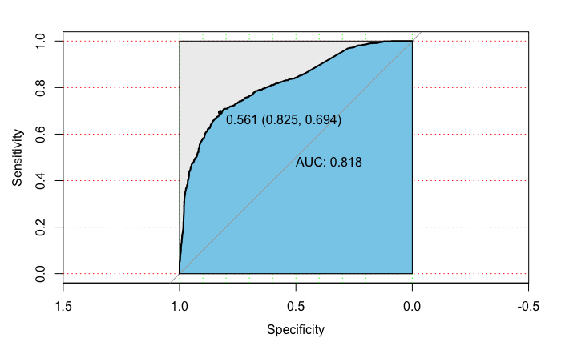

```r
# 画ROC图像
m<-pROC::roc(test_final_df$y,prob_test3_2)
plot(m,print.auc=TRUE, auc.polygon=TRUE, grid=c(0.1, 0.2),
     grid.col=c("green", "red"), max.auc.polygon=TRUE,
     auc.polygon.col="skyblue", print.thres=TRUE)
```

SVM模型1的AUC高达0.818，呈现出良好的分类效果。  
SVM模型1的等误差率为0.561，不处于一个较低水平。

#### 精准率，召回率，F值

```r
precision_0 <- sum(subset(table_test_df3,pre_test3==0&Var2==0)$Freq)/sum(subset(table_test_df3,pre_test3==0)$Freq)
precision_1 <- sum(subset(table_test_df3,pre_test3==1&Var2==1)$Freq)/sum(subset(table_test_df3,pre_test3==1)$Freq)

recall_0 <- sum(subset(table_test_df3,pre_test3==0&Var2==0)$Freq)/sum(subset(table_test_df3,Var2==0)$Freq)
recall_1 <- sum(subset(table_test_df3,pre_test3==1&Var2==1)$Freq)/sum(subset(table_test_df3,Var2==1)$Freq)

F_score_0 <- 2*(precision_0*recall_0)/(precision_0+recall_0)
F_score_1 <- 2*(precision_1*recall_1)/(precision_1+recall_1)

cat(paste0('测试集-label0精确率：',precision_0,'\n',
           '测试集-label0召回率：',recall_0,'\n',
           '测试集-label0 Fscore：',F_score_0,'\n'
           ),'\n')
```

```
测试集-label0精确率：0.729479768786127
测试集-label0召回率：0.828083989501312
测试集-label0 Fscore：0.775660725261217
```

```r
cat(paste0('测试集-label1精确率：',precision_1,'\n',
           '测试集-label1召回率：',recall_1,'\n',
           '测试集-label1 Fscore：',F_score_1,'\n'
           ),'\n')
```

```
测试集-label1精确率：0.793700787401575
测试集-label1召回率：0.682926829268293
测试集-label1 Fscore：0.734158776402039
```

### 6.2.2 kernel=‘polynomial’

这里建模分析步骤与前部分相似，故不再阐述，只进行对比分析结果。

#### 模型训练

```r
svm_model <- e1071::svm(y~.,data=train_final_df,kernel='polynomial', probability=TRUE)
```

```r
summary(svm_model)
```

```
Call:
svm(formula = y ~ ., data = train_final_df, kernel = "polynomial", probability = TRUE)


Parameters:
   SVM-Type:  C-classification
 SVM-Kernel:  polynomial
       cost:  1
     degree:  3
      gamma:  0.003021148
     coef.0:  0

Number of Support Vectors:  6407

 ( 3197 3210 )


Number of Classes:  2

Levels:
 0 1
```

#### 模型预测

```r
pre_train3 <-
predict(svm_model, train_final_df[1:(ncol(train_final_df) - 1)])

pre_test3 <-
predict(svm_model, test_final_df[1:(ncol(test_final_df) - 1)])

prob_test3 <-
predict(svm_model, test_final_df[1:(ncol(test_final_df) - 1)], probability = TRUE)
prob_test3_2 <- attr(prob_test3, "probabilities")[,'1']
```

```r
str(prob_test3)
```

```
 Factor w/ 2 levels "0","1": 1 1 2 1 1 1 1 1 1 2 ...
 - attr(*, "names")= chr [1:3000] "1" "2" "3" "4" ...
 - attr(*, "probabilities")= num [1:3000, 1:2] 0.511 0.501 0.499 0.527 0.501 ...
  ..- attr(*, "dimnames")=List of 2
  .. ..$ : chr [1:3000] "1" "2" "3" "4" ...
  .. ..$ : chr [1:2] "0" "1"
```

#### 模型效果

```r
table_train_df3 <- as.data.frame(table(pre_train3, train_final_df$y))
x1 <-
sum(subset(table_train_df3, pre_train3 == Var2)$Freq) / sum(table_train_df3$Freq)

table_test_df3 <- as.data.frame(table(pre_test3, test_final_df$y))
x2 <-
sum(subset(table_test_df3, pre_test3 == Var2)$Freq) / sum(table_test_df3$Freq)
cat(paste0('模型2训练集准确率：', x1, '\n', '测试集准确率：', x2))
```

```
模型2训练集准确率：0.781714285714286
测试集准确率：0.620666666666667
```

训练集的准确率为78%，测试集的准确率为62%，远低于模型1的效果

```r
#混淆矩阵
table(pre_train3,train_final_df$y)
```

```
pre_train3    0    1
         0 3278 1333
         1  195 2194
```

```r
table(pre_test3,test_final_df$y)
```

```
pre_test3    0    1
        0 1216  830
        1  308  646
```

```r
# 拼接成函数需要的数据格式
pred <- ROCR::prediction(prob_test3_2,test_final_df$y)
# 计算AUC
ROCR::performance(pred,'auc')@y.values #AUC值
```

```
[[1]]
[1] 0.6997645
```

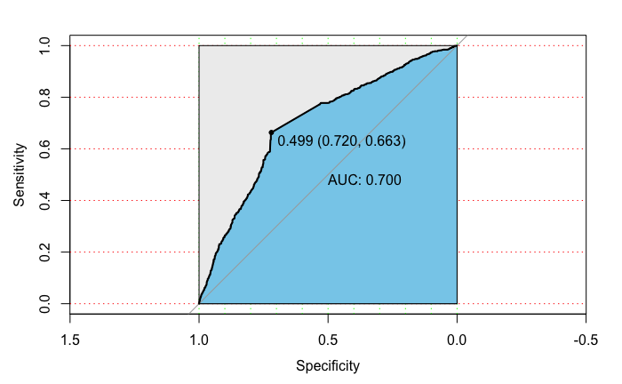

```r
# 画ROC图像
m<-pROC::roc(test_final_df$y,prob_test3_2)
plot(m,print.auc=TRUE, auc.polygon=TRUE, grid=c(0.1, 0.2),
     grid.col=c("green", "red"), max.auc.polygon=TRUE,
     auc.polygon.col="skyblue", print.thres=TRUE)
```

#### 精准率，召回率和F值

```r
precision_0 <- sum(subset(table_test_df3,pre_test3==0&Var2==0)$Freq)/sum(subset(table_test_df3,pre_test3==0)$Freq)
precision_1 <- sum(subset(table_test_df3,pre_test3==1&Var2==1)$Freq)/sum(subset(table_test_df3,pre_test3==1)$Freq)

recall_0 <- sum(subset(table_test_df3,pre_test3==0&Var2==0)$Freq)/sum(subset(table_test_df3,Var2==0)$Freq)
recall_1 <- sum(subset(table_test_df3,pre_test3==1&Var2==1)$Freq)/sum(subset(table_test_df3,Var2==1)$Freq)

F_score_0 <- 2*(precision_0*recall_0)/(precision_0+recall_0)
F_score_1 <- 2*(precision_1*recall_1)/(precision_1+recall_1)

cat(paste0('测试集-label0精确率：',precision_0,'\n',
           '测试集-label0召回率：',recall_0,'\n',
           '测试集-label0 Fscore：',F_score_0,'\n'
           ),'\n')
```

```
测试集-label0精确率：0.594330400782014
测试集-label0召回率：0.797900262467192
测试集-label0 Fscore：0.681232492997199
```

```r
cat(paste0('测试集-label1精确率：',precision_1,'\n',
           '测试集-label1召回率：',recall_1,'\n',
           '测试集-label1 Fscore：',F_score_1,'\n'
           ),'\n')
```

```
测试集-label1精确率：0.677148846960168
测试集-label1召回率：0.437669376693767
测试集-label1 Fscore：0.531687242798354
```

## 6.3 xgb

### 6.3.1 模型训练

```r
library(xgboost)  # 载入库
param <- list(max_depth = 2, eta = 1, nthread = 2, silent = 1,
              objective = "binary:logistic", eval_metric = "error")   # 设置树的最大深度为2;eta = 1用于更新叶子节点权重时，乘以该系数，避免步长过大;silent = 1表示静态模式开启，不输出中间过程；目标函数为二分类的逻辑回归，返回预测的概率；按照error进行模型优化。
xgb_model <- xgboost::xgboost(
data = data.matrix(train_final_df[1:(ncol(train_final_df) - 1)]),  # xgb对数据的格式有要求，把数据框变成矩阵
label = as.numeric(as.character(train_final_df$y)),   # 现在不需要因子型的label,因此把因子转换成数值型
nrounds = 500,  # 一次一次去预测，预测500次
params = param,
seed = 12345, # 随机种子，复现随机数据的结果
verbose=0 # 不打印消息，否则会把每次预测的结果打印出来
)
View(testset_raw)
```

### 6.3.2 变量重要性

反应变量重要性,将影响最大的10个变量可视化：

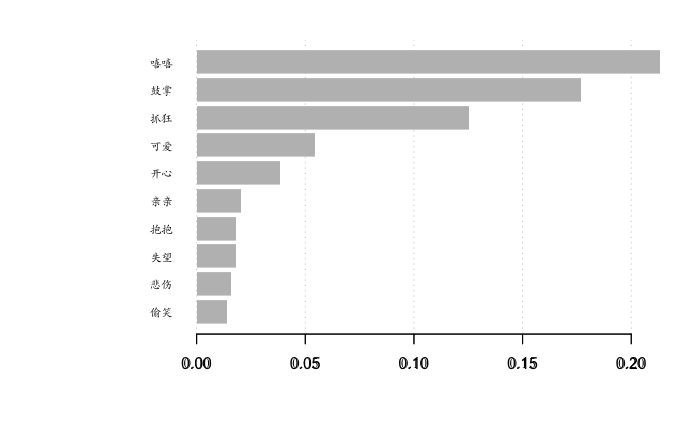

```r
# 计算特征重要性矩阵
importance_matrix <- xgboost::xgb.importance(colnames(train_final_df)[1:727],model = xgb_model)
# 制图
xgboost::xgb.plot.importance(importance_matrix[1:10,],family='STKaiti') # 取排名前10的变量
```

### 6.3.3 模型预测

```r
# 对训练集进行预测
prob_train4 <-
predict(xgb_model, data.matrix(train_final_df[1:(ncol(train_final_df) - 1)]))
pre_train4 <- ifelse(prob_train4 > 0.5, 1, 0)
# 对测试集进行预测
prob_test4 <-
predict(xgb_model, data.matrix(test_final_df[colnames(train_final_df)][1:(ncol(test_final_df) - 1)])) # 数据框虽然列名一样，但列的位置不一定一样，xgb对此有严格要求，因此要把列名排成一致的。
pre_test4 <- ifelse(pre_test4 > 0.5, 1, 0) # 返回的结果是一个概率，需要做判断，大于0.5时为1.
# 展示一下
str(prob_train4)
```

```
 num [1:7000] 0.01476 0.97992 0.38111 0.00284 0.9817 ...
```

```r
str(pre_train4)
```

```
 num [1:7000] 0 1 0 0 1 0 0 0 0 1 ...
```

```r
str(prob_test4)
```

```
 num [1:3000] 0.00819 0.38111 0.92693 0.00254 0.38111 ...
```

```r
str(pre_test4)
```

```
 num [1:3000] 0 0 1 0 0 1 0 0 0 0 ...
```

### 6.3.4 模型效果及其可视化

```r
table_train_df4 <- as.data.frame(table(pre_train4, train_final_df$y)) # 转换为数据框
x1 <-
sum(subset(table_train_df4, pre_train4 == Var2)$Freq) / sum(table_train_df4$Freq) # 训练集的准确率

table_test_df4 <- as.data.frame(table(pre_test4, test_final_df$y)) # 转换为数据框
x2 <-
sum(subset(table_test_df4, pre_test4 == Var2)$Freq) / sum(table_test_df4$Freq) # subset()用于取子集，x2为测试集的准确率
cat(paste0('训练集准确率：', x1, '\n', '测试集准确率：', x2)) # 连接后打印出来，且不会出现序号。
```

```
训练集准确率：0.826285714285714
测试集准确率：0.770333333333333
```

训练集的准确率82.63%，测试集77.03%

#### 混淆矩阵

```r
# 行是预测的label,列是真实的label,交叉 对角线是预测label=真实label
table(pre_train4,train_final_df$y)
```

```
pre_train4    0    1
         0 3128  871
         1  345 2656
```

```r
table(pre_test4,test_final_df$y)
```

```
pre_test4    0    1
        0 1255  420
        1  269 1056
```

#### 绘制ROC曲线和AUC值

```r
library(ROCR) #加载ROCR包
# 拼接成函数需要的数据格式
pred <- ROCR::prediction(prob_test4,test_final_df$y)
# 计算AUC
ROCR::performance(pred,'auc')@y.values  # AUC值
```

```
[[1]]
[1] 0.8502068
```

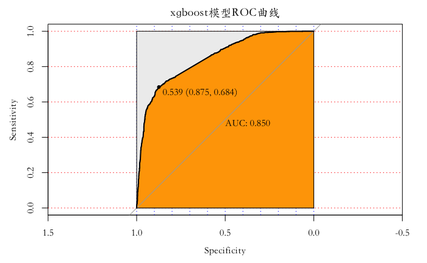

```r
# 画图像
perf <- pROC::roc(test_final_df$y,prob_test4)
plot(perf,print.auc=TRUE, auc.polygon=TRUE, grid=c(0.1, 0.2),
     grid.col=c("blue", "red"), max.auc.polygon=TRUE,
     auc.polygon.col="orange", print.thres=TRUE,main='xgboost模型ROC曲线',family='STKaiti')  # 调用plot函数绘制roc曲线，并设置图的参数,网格线为蓝色和红色，所围面积用橙色
```

由图可见，xgb模型的AUC高达0.850，呈现出良好的分类效果。  
xgb模型的等误差率为0.539(0.875,0.684)，准确效果还可以。

### 6.3.5 精准率，召回率和F值

```r
# 测试集-label0精确率，在判断为真的样例中，实际为真的样例比例。
precision_0 <- sum(subset(table_train_df4,pre_train4==0&Var2==0)$Freq)/sum(subset(table_train_df4,pre_train4==0)$Freq)
# 测试集-label1精确率，在判断为真的样例中，实际为真的样例比例。
precision_1 <- sum(subset(table_train_df4,pre_train4==1&Var2==1)$Freq)/sum(subset(table_train_df4,pre_train4==1)$Freq)
# 测试集-label0召回率，在实际为真的样例中，被判断为真的样例比例。
recall_0 <- sum(subset(table_train_df4,pre_train4==0&Var2==0)$Freq)/sum(subset(table_train_df4,Var2==0)$Freq)
# 测试集-label1召回率，在实际为真的样例中，被判断为真的样例比例。
recall_1 <- sum(subset(table_train_df4,pre_train4==1&Var2==1)$Freq)/sum(subset(table_train_df4,Var2==1)$Freq)

# 测试集-label0和测试集-label1的f值，F = （2*P*R）/(P+R)
F_score_0 <- 2*(precision_0*recall_0)/(precision_0+recall_0)
F_score_1 <- 2*(precision_1*recall_1)/(precision_1+recall_1)

cat(paste0('测试集-label0精确率：',precision_0,'\n',
           '测试集-label0召回率：',recall_0,'\n',
           '测试集-label0 Fscore：',F_score_0,'\n'
           ),'\n')
```

[output not shown]

```r
cat(paste0('测试集-label1精确率：',precision_1,'\n',
           '测试集-label1召回率：',recall_1,'\n',
           '测试集-label1 Fscore：',F_score_1,'\n'
           ),'\n')
```

[output not shown]

### 6.3.6 进行调参-寻找最优模型

通过网格搜索的方式，以模型预测的准确度为指标，对模型进行调参，并筛选最优参数。

xgb中的主要参数，故下面依次对这三个参数进行调参 eta 默认值设置为0.3。需要指定用于更新步长收缩来防止过度拟合。每个提升步骤后,可以直接获得新特性的权重。实际上 eta 收缩特征权重的提高过程更为保守。范围是0到1。低η值意味着模型过度拟合更强。 max_ depth 默认值设置为6，需要指定一个树的最大深度。参数范围是1到∞ ∞ nround 迭代次数

```r
library(lattice)
library(ggplot2)
library(xgboost)
library(caret)
```

```r
# 构建结果矩阵
result_xgb=matrix(0,10,6)  # 创建一个matrix用于接收调参的结果，然后进行比较
colnames(result_xgb)=c("id","max_depth","etai","nrounds","acu_train","acu_test") # 为matrix修改列名称

max_depthi=2 # 设置初始值 max_depth=2
etai=0.1     # 设置初始值 eta=0.1
nroundsi=0   # 设置初始值 nround=0
```

利用循环，一次次对 “max_depth”,“etai”,“nrounds” 进行调参，并记录模型对训练集和预测集的效果：

```r
#对nrounds进行调参数，max_depth和etai保持不变。
for (i in (1:10)){
    # max_depthi=max_depthi+2
    # etai=etai+0.1
    nroundsi=nroundsi+100 # nrounds每次递增100，对nrounds进行调参数，先保持另外两个不变，把两外两个注释掉。

    # 设置参数，同上
    param <- list(max_depth = max_depthi, eta = etai, nthread = 2, silent = 1,
                  objective = "binary:logistic", eval_metric = "error")
    xgb_model <- xgboost::xgboost(
    data = data.matrix(train_final_df[1:(ncol(train_final_df) - 1)]),
    label = as.numeric(as.character(train_final_df$y)),
    nrounds = nroundsi,
    params = param,
    seed = 12345,
    verbose=0 # 不打印消息
    )

    # 对结果进行预测
    pre_train4 <-round(predict(xgb_model, data.matrix(train_final_df[1:(ncol(train_final_df) - 1)]))) # 对训练集进行预测，round直接取整，大于0.5的为1，小于0.5的为0
    pre_test4 <-round(predict(xgb_model, data.matrix(test_final_df[colnames(train_final_df)][1:(ncol(test_final_df) - 1)]))) # 对测试集进行预测

    # 构建训练集结果矩阵
    caret::confusionMatrix(factor(pre_train4), train_final_df$y)  # 构建并打印混淆矩阵
    matrix_t1= caret::confusionMatrix(factor(pre_train4), train_final_df$y) # 取训练集的accuracy值
    accuracy1=matrix_t1$overall[1] # 取训练集的accuracy值

    # 构建预测集结果矩阵
    caret::confusionMatrix(factor(pre_test4), test_final_df$y)  # 构建并打印混淆矩阵
    matrix_t2= caret::confusionMatrix(factor(pre_test4), test_final_df$y) # 取测试集的accuracy值
    accuracy2=matrix_t2$overall[1] # 取测试集的accuracy值

    # 将结果写入结果矩阵
    result_xgb[i,1]=i            #result_xgb第一列 为i及id
    result_xgb[i,2]=max_depthi   #result_xgb第二列 max_depthi
    result_xgb[i,3]=etai         #result_xgb第二列 etai
    result_xgb[i,4]=nroundsi     #result_xgb第二列 nroundsi
    result_xgb[i,5]=accuracy1    #result_xgb第二列 accuracy1
    result_xgb[i,6]=accuracy2    #result_xgb第二列 accuracy2
}
result_xgb # 输出 result_xgb进行结果对比。
```

[output not shown]

随着nrounds的增加，训练集的accuracy值一直在提高，但是测试集存在降低，说明出现了过拟合，模型的泛化能力在下降，即模型预测能力在下降，所以由图显示，nrounds就等于400是最好的，因为主要看xgb模型在测试集的表现，即为最后一列。

```r
max_depthi=2 # 设置初始值 max_depth=2
etai=0.1     # 设置初始值 eta=0.1
nroundsi=100   # 重新设置初始值 nround=300

#对max_depth进行调参数，nrounds和etai保持不变。
for (i in (1:10)){
    max_depthi=max_depthi+2 # 深度每次递增2，对max_depth进行调参数，保持另外两个不变，把两外两个注释掉。
    # etai=etai+0.1
    # nroundsi=nroundsi+100

    # 设置参数，同上
    param <- list(max_depth = max_depthi, eta = etai, nthread = 2, silent = 1,
                  objective = "binary:logistic", eval_metric = "error")
    xgb_model <- xgboost::xgboost(
    data = data.matrix(train_final_df[1:(ncol(train_final_df) - 1)]),
    label = as.numeric(as.character(train_final_df$y)),
    nrounds = nroundsi,
    params = param,
    seed = 12345,
    verbose=0 # 不打印消息
    )

    # 对结果进行预测
    pre_train4 <-round(predict(xgb_model, data.matrix(train_final_df[1:(ncol(train_final_df) - 1)]))) # 对训练集进行预测，round直接取整，大于0.5的为1，小于0.5的为0
    pre_test4 <-round(predict(xgb_model, data.matrix(test_final_df[colnames(train_final_df)][1:(ncol(test_final_df) - 1)]))) # 对测试集进行预测

    # 构建训练集结果矩阵
    caret::confusionMatrix(factor(pre_train4), train_final_df$y)  # 构建并打印混淆矩阵
    matrix_t1= caret::confusionMatrix(factor(pre_train4), train_final_df$y) # 取训练集的accuracy值
    accuracy1=matrix_t1$overall[1] # 取训练集的accuracy值

    # 构建预测集结果矩阵
    caret::confusionMatrix(factor(pre_test4), test_final_df$y)  # 构建并打印混淆矩阵
    matrix_t2= caret::confusionMatrix(factor(pre_test4), test_final_df$y) # 取测试集的accuracy值
    accuracy2=matrix_t2$overall[1] # 取测试集的accuracy值

    # 将结果写入结果矩阵
    result_xgb[i,1]=i            #result_xgb第一列 为i及id
    result_xgb[i,2]=max_depthi   #result_xgb第二列 max_depthi
    result_xgb[i,3]=etai         #result_xgb第二列 etai
    result_xgb[i,4]=nroundsi     #result_xgb第二列 nroundsi
    result_xgb[i,5]=accuracy1    #result_xgb第二列 accuracy1
    result_xgb[i,6]=accuracy2    #result_xgb第二列 accuracy2
}
result_xgb # 输出 result_xgb进行结果对比。
```

```
      id max_depth etai nrounds acu_train  acu_test
 [1,]  1         4  0.1     100 0.7841429 0.7650000
 [2,]  2         6  0.1     100 0.7950000 0.7713333
 [3,]  3         8  0.1     100 0.8012857 0.7723333
 [4,]  4        10  0.1     100 0.8090000 0.7743333
 [5,]  5        12  0.1     100 0.8134286 0.7763333
 [6,]  6        14  0.1     100 0.8180000 0.7786667
 [7,]  7        16  0.1     100 0.8192857 0.7780000
 [8,]  8        18  0.1     100 0.8232857 0.7803333
 [9,]  9        20  0.1     100 0.8242857 0.7810000
[10,] 10        22  0.1     100 0.8272857 0.7783333
```

由上图显示，当max_depth=20时，测试集accuracy值最高，模型表现最优，但随着深度的继续增加，模型在测试集的准确率开始下降，说明模型可能出现了过拟合，所以最优时应为深度为20，但树的深度对模型训练时间的影响较大，且树深为4到树深为20之间的测试集准确率相差的很小，此时需要考虑模型的运行效率，因此采用树深度为4。

```r
max_depthi=2 # 设置初始值 max_depth=2
etai=0.1     # 设置初始值 eta=0.1
nroundsi=100   # 重新设置初始值 nround=100

#对eta进行调参数，nrounds和max_depth保持不变。
for (i in (1:10)){
    # max_depthi=max_depthi+2
     etai=etai+0.1   # 每次递增0.1，对eta进行调参数，保持另外两个不变，把两外两个注释掉。
    # nroundsi=nroundsi+100

    # 设置参数，同上
    param <- list(max_depth = max_depthi, eta = etai, nthread = 2, silent = 1,
                  objective = "binary:logistic", eval_metric = "error")
    xgb_model <- xgboost::xgboost(
    data = data.matrix(train_final_df[1:(ncol(train_final_df) - 1)]),
    label = as.numeric(as.character(train_final_df$y)),
    nrounds = nroundsi,
    params = param,
    seed = 12345,
    verbose=0 # 不打印消息
    )

    # 对结果进行预测
    pre_train4 <-round(predict(xgb_model, data.matrix(train_final_df[1:(ncol(train_final_df) - 1)]))) # 对训练集进行预测，round直接取整，大于0.5的为1，小于0.5的为0
    pre_test4 <-round(predict(xgb_model, data.matrix(test_final_df[colnames(train_final_df)][1:(ncol(test_final_df) - 1)]))) # 对测试集进行预测

    # 构建训练集结果矩阵
    caret::confusionMatrix(factor(pre_train4), train_final_df$y)  # 构建并打印混淆矩阵
    matrix_t1= caret::confusionMatrix(factor(pre_train4), train_final_df$y) # 取训练集的accuracy值
    accuracy1=matrix_t1$overall[1] # 取训练集的accuracy值

    # 构建预测集结果矩阵
    caret::confusionMatrix(factor(pre_test4), test_final_df$y)  # 构建并打印混淆矩阵
    matrix_t2= caret::confusionMatrix(factor(pre_test4), test_final_df$y) # 取测试集的accuracy值
    accuracy2=matrix_t2$overall[1] # 取测试集的accuracy值

    # 将结果写入结果矩阵
    result_xgb[i,1]=i            #result_xgb第一列 为i及id
    result_xgb[i,2]=max_depthi   #result_xgb第二列 max_depthi
    result_xgb[i,3]=etai         #result_xgb第二列 etai
    result_xgb[i,4]=nroundsi     #result_xgb第二列 nroundsi
    result_xgb[i,5]=accuracy1    #result_xgb第二列 accuracy1
    result_xgb[i,6]=accuracy2    #result_xgb第二列 accuracy2
}
result_xgb # 输出 result_xgb进行结果对比。
```

```
      id max_depth etai nrounds acu_train  acu_test
 [1,]  1         2  0.2     100 0.7805714 0.7643333
 [2,]  2         2  0.3     100 0.7917143 0.7706667
 [3,]  3         2  0.4     100 0.7957143 0.7703333
 [4,]  4         2  0.5     100 0.8032857 0.7723333
 [5,]  5         2  0.6     100 0.8118571 0.7770000
 [6,]  6         2  0.7     100 0.8151429 0.7750000
 [7,]  7         2  0.8     100 0.8155714 0.7690000
 [8,]  8         2  0.9     100 0.8170000 0.7773333
 [9,]  9         2  1.0     100 0.8215714 0.7760000
[10,] 10         2  1.1     100 0.8222857 0.7723333
```

由图显示，eta=0.9时，测试集的表现最优，因此选用eta=0.9。

由上面三个调参可得，最终得到的最优模型参数如下： max_depth=4, eta=0.9，nrounds=400。

### 6.3.7 构建最优模型

```r
max_depthi=4 #设置初始值 max_depth=4
etai=0.9     #设置初始值 eta=0.9
nroundsi=400 #设置初始值 nround=400
```

```r
#设置参数，构建最优模型，同上
param <- list(max_depth = max_depthi, eta = etai, nthread = 2, silent = 1,
              objective = "binary:logistic", eval_metric = "error")
xgb_model_best <- xgboost::xgboost(
data = data.matrix(train_final_df[1:(ncol(train_final_df) - 1)]),
label = as.numeric(as.character(train_final_df$y)),
nrounds = nroundsi,
params = param,
seed = 12345,
verbose=0 # 不打印消息
)
```

### 6.3.8 查看树模型

```r
library(DiagrammeR) #加载DiagrammeR包
library(ggplot2)
library(xgboost)
p <- xgb.plot.multi.trees(model = xgb_model_best,features_keep = 3) #调用xgb中 xgb.plot.multi.trees函数打印模型的树结构
print(p) #将树结构输出
```

由于树模型在rmd中可以运行却无法通过preview生成结果,故此处用截图展示。

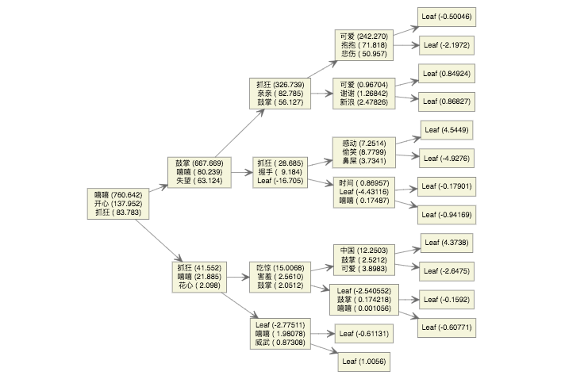

```r
image_path = "../Picture/树模型.png"
rmarkdown::html_notebook_output_img(path = image_path, format = "png")
```

## 6.4 朴素贝叶斯

### 6.4.1 模型训练

```r
# 直接调用

#参数laplace是一个优化参数
naiveBayes_model <-
  e1071::naiveBayes(train_final_df[1:(ncol(train_final_df) - 1)],
                                   train_final_df$y, laplace = 1)
```

### 6.4.2 模型预测

```r
pre_train1 <-
  predict(naiveBayes_model, train_final_df[1:(ncol(train_final_df) - 1)])

  pre_test1 <-
  predict(naiveBayes_model, test_final_df[1:(ncol(test_final_df) - 1)])
   prob_test1 <-
  predict(naiveBayes_model, test_final_df[1:(ncol(test_final_df) - 1)],type = 'raw')[,2]
```

### 6.4.3 模型效果

```r
table_train_df1 <- as.data.frame(table(pre_train1,train_final_df$y))
x1 <- sum(subset(table_train_df1,pre_train1==Var2)$Freq)/sum(table_train_df1$Freq)

table_test_df1 <- as.data.frame(table(pre_test1,test_final_df$y))
x2 <- sum(subset(table_test_df1,pre_test1==Var2)$Freq)/sum(table_test_df1$Freq)
cat(paste0('训练集准确率：',x1,'\n','测试集准确率：',x2))
```

[output not shown]

### 6.4.4 ROC

```r
# 拼接成函数需要的数据格式
pred <- pROC::roc(test_final_df$y,prob_test1)
plot(pred,print.auc=TRUE, auc.polygon=TRUE, grid=c(0.1, 0.2),
     grid.col=c("green", "red"), max.auc.polygon=TRUE,
     auc.polygon.col="green", print.thres=TRUE)
```

[output not shown]

### 6.4.5 计算精确率和召回率

```r
Var1<-0
precision_0 <- sum(subset(table_test_df1,pre_test1==0&Var1==0)$Freq)/sum(subset(table_test_df1,pre_test1==0)$Freq)
recall_0 <- sum(subset(table_test_df1,pre_test1==0&Var1==0)$Freq)/sum(subset(table_test_df1,Var1==0)$Freq)
Var1<-1
precision_1 <- sum(subset(table_test_df1,pre_test1==1&Var1==1)$Freq)/sum(subset(table_test_df1,pre_test1==1)$Freq)
recall_1 <- sum(subset(table_test_df1,pre_test1==1&Var1==1)$Freq)/sum(subset(table_test_df1,Var1==1)$Freq)

#计算F值
F_score_0 <- 2*(precision_0*recall_0)/(precision_0+recall_0)
F_score_1 <- 2*(precision_1*recall_1)/(precision_1+recall_1)

cat(paste0('测试集-label0精确率：',precision_0,'\n',
           '测试集-label0召回率：',recall_0,'\n',
           '测试集-label0 Fscore：',F_score_0,'\n'
           ),'\n')
cat(paste0('测试集-label1精确率：',precision_1,'\n',
           '测试集-label1召回率：',recall_1,'\n',
           '测试集-label1 Fscore：',F_score_1,'\n'
           ),'\n')
```

[output not shown]

# 7 结果与分析

## 7.2 针对词云的结论

- 通过词云统计，我们发现网友们表达情感多喜爱用“微博表情”以及语气词进行传递，例如表达喜悦的情绪多用 “嘻嘻”“鼓掌”等语气词或者表情；而表达沮丧的情绪时多用“抓狂”“伤心”这样的词语进行描述
- 通过分词的结果可知，人们表达情感多用的动词进行传递，而非名词、形容词、副词等。

## 7.3 针对现实意义

- 通过网友微博的评论，可以通过分类算法判断改网友的情绪是正向还是负向。经过这样的自动处理，可以简单的判别出网友针对某一件事情的情感，例如：对当下华为事件的态度是积极还是消极、对明星某些行为是认可的还是反对的。
- 通过选取最优的分类模型，对网友的微博评论进行情感标注，一方面可以为广大机器学习爱好者提供带有标注的数据集，另一方方面可以扩充语料库。
- 上述的文本数据预处理以及分类算法，不仅在适用于微博评论的情感分析，它同样适用于电商评价以及电影的评价的情感分析，具有普适性。例如：淘宝商家通过买家的评论来揣测消费者的喜好，以方便其进行个性化定制。

# 8 总结

本文以新浪微博信息为研究对象,利用带有情感标记的微博中文文本进行情感分类。在对数据进行简单展示后，通过词云的方式更加生动展出研究数据；在对数据进行预处理后,利用贝叶斯算法、SVM、随机森林以及xgb分类算法对数据进行情感分析, 最终经过比较实验过程和实验结果,发现四种在分类速度和精度上各有优劣,四种算法对微博信息情感分析是有效的。同时为了提高程序的运行效率,本文还在程序中引入了文本合并的创新点,使情感分析运行效率得到显著提高。

# 9 参考文献列表

词云  
R语言之词云：wordcloud&wordcloud2安装及参数https://www.cnblogs.com/hadoopdev/p/5697546.html https://blog.csdn.net/zhouhucheng00/article/details/85854468

svm  
[1]张燕,姚志远,陈文社.支持向量机在文本分类中的研究与应用[J].电脑编程技巧与维护,2018(08):68-69+85. [2]王鹤琴,王杨.基于情感倾向和SVM混合极短文本分类模型[J].科技通报,2018,34(08):149-154. [3]张庆庆,刘西林.基于机器学习的中文微博情感分类研究[J].未来与发展,2015,39(04):59-63. [4]https://zhuanlan.zhihu.com/p/25188759  
[5]https://cran.r-project.org/web/packages/e1071/e1071.pdf https://blog.csdn.net/xspyzm/article/details/77428546 https://blog.csdn.net/weixin_36372879/article/details/80525926

随机森林  
[1]Scott V.Burger.基于R语言的机器学习. 北京:中国电力出版社, 2018.11. [2]于卫红. R语言与网络舆情处理. 北京:清华大学出版, 2018. [3]李航. 统计学习方法. 北京:清华大学出版社. [4]杨艳霞. 基于分类的微博情感分析算法研究及实现[J]. 2017.02. [5]冯成刚,田大钢.基于机器学习的微博情感分类研究[J].软件导刊. 2018(06). [6] https://qinwenfeng.com/jiebaR/ [7] https://www.cnblogs.com/nxld/p/6374945.html [8] https://blog.csdn.net/xwd18280820053/article/details/70674256 [9] https://blog.csdn.net/wendaomudong_l2d4/article/details/78500747 [10] https://blog.csdn.net/wendaomudong_l2d4/article/details/71375241

xgb  
[1]https://blog.csdn.net/wufengqi7585/article/details/86078049 [2]https://zhuanlan.zhihu.com/p/20871600  
[3]二分类模型评价指标-ROC&PRC https://blog.csdn.net/wendaomudong_l2d4/article/details/71375241 [4]https://www.cnblogs.com/Sugar-Chl/p/10168838.html [5]https://www.cnblogs.com/pengwang52/p/9623093.html [6]https://blog.csdn.net/ruding/article/details/78328835 [7]https://blog.csdn.net/a52654/article/details/80841704?utm_source=blogxgwz2 [8]http://m.sohu.com/a/223678289_505915 [9]https://blog.csdn.net/ccblogger/article/details/81865540 [10]Scott V.Burger.基于R语言的机器学习. 北京:中国电力出版社, 2018.11. [11]谢丽星，周明，孙茂松.基于层次结构的多策略中文微 博 情 感 分 析 和 特 征 抽 取 [J].中 文 信 息 学 报 ，2012，26 (1):73-83.

朴素贝叶斯  
[1]焦凤.基于朴素贝叶斯的酒店评论情感倾向性分析[J].现代计算机(专业版),2018(20):45-49. [2]]张俊飞.基于改进朴素贝叶斯算法实现评教评语情感分析[J].现代计算机(专业版),2018(32):3-6. [3]于营.基于朴素贝叶斯的旅游网情感分类研究[J].信息与电脑(理论版),2018(18):50-51+55. [4]陈强. 基于社交网络的用户情感分析方法研究[D].重庆邮电大学,2016.